| pSERG |
| --- |

## Load needed packages

This step loads packages with functions needed for analysis that are not included in basic R.

```r
#install.packages("gmodels")
library(gmodels)

#install.packages("gdata")
library(gdata)
#install.packages("survival")
library(survival)

#install.packages("alluvial")
library(alluvial)
#install.packages("survminer")
library(survminer)
#install.packages("dplyr")
library(dplyr)
```

## Load the database

Load the pSERG database into R.

```r
# Load pSERG database
pSERG <- read.csv("C:\\Users\\marta\\Documents\\PROJECTS\\EMS - PREHOSPITAL MANAGEMENT OF SE\\pserg_2020EMS.csv")
```

## Clean the database

Keep only the population of interest and transform variables for analysis.

```r
# Keep only patients who have refractory status epilepticus
pSERG <- pSERG[which(pSERG$SE_GROUP == "refractory_case"), ]
dim(pSERG)
```

```
## [1]  502 1582
```

```r
# Keep only patients who have RSE initated outside the hospital
pSERG <- pSERG[which(pSERG$HOSPITALONSET == "no"), ]
dim(pSERG)
```

```
## [1]  340 1582
```

```r
# Time from SE onset to EMS arrival (EMSARRIVAL)
class(pSERG$EMSARRIVAL)
```

```
## [1] "factor"
```

```r
pSERG$EMSARRIVAL <- as.character(as.factor(pSERG$EMSARRIVAL))
pSERG$EMSARRIVAL <- as.numeric(as.character(pSERG$EMSARRIVAL))
dim(pSERG)
```

```
## [1]  340 1582
```

```r
# Time from SE onset to hospital arrival (HOSPITALARRIVAL)
class(pSERG$HOSPITALARRIVAL)
```

```
## [1] "factor"
```

```r
pSERG$HOSPITALARRIVAL <- as.character(as.factor(pSERG$HOSPITALARRIVAL))
pSERG$HOSPITALARRIVAL <- as.numeric(as.character(pSERG$HOSPITALARRIVAL))
dim(pSERG)
```

```
## [1]  340 1582
```

```r
# Time to first BZD (BZD.TIME0)
class(pSERG$BZDTIME.0)
```

```
## [1] "factor"
```

```r
pSERG$BZDTIME.0 <- as.character(as.factor(pSERG$BZDTIME.0))
pSERG$BZDTIME.0 <- as.numeric(as.character(pSERG$BZDTIME.0))
#Time to first AED (AED.TIME0)
class(pSERG$AEDTIME.0)
```

```
## [1] "factor"
```

```r
pSERG$AEDTIME.0 <- as.character(as.factor(pSERG$AEDTIME.0))
pSERG$AEDTIME.0 <- as.numeric(as.character(pSERG$AEDTIME.0))
# Delete patients with unknown EMSARRIVAL
pSERG <- pSERG[complete.cases(pSERG[ , "EMSARRIVAL"]), ]
dim(pSERG)
```

```
## [1]  132 1582
```

```r
pSERG <- pSERG[which(pSERG$EMSARRIVAL > 0), ]
dim(pSERG)
```

```
## [1]  129 1582
```

```r
# Delete patients with unknown HOSPITALARRIVAL
pSERG <- pSERG[complete.cases(pSERG[ , "HOSPITALARRIVAL"]), ]
dim(pSERG)
```

```
## [1]  114 1582
```

```r
# Delete patients with NA BZDTIME
pSERG <- pSERG[complete.cases(pSERG[ , "BZDTIME.0"]), ]
dim(pSERG)
```

```
## [1]  110 1582
```

```r
# Delete patients with NA AEDTIME
pSERG <- pSERG[complete.cases(pSERG[ , "AEDTIME.0"]), ]
dim(pSERG)
```

```
## [1]   96 1582
```

```r
# Time in the ambulance
pSERG$timeinambulance <- pSERG$HOSPITALARRIVAL - pSERG$EMSARRIVAL


# Transform date of status epilepticus onset into date format
pSERG$DATESEIZURE <- as.Date(pSERG$DATESEIZURE, format = "%m/%d/%Y")

# Order by patient and then by date of status epilepticus
pSERG <- pSERG[order(pSERG$PATIENT_LABEL, pSERG$DATESEIZURE), ]

# Delete duplicate episodes from the same patient
pSERG <- pSERG[!duplicated(pSERG$PATIENT_LABEL), ]
dim(pSERG)
```

```
## [1]   91 1583
```

```r
summary(pSERG$BZDTIME.0)
```

```
##    Min. 1st Qu.  Median    Mean 3rd Qu.    Max.
##    0.00    5.00   20.00   60.91   31.00 1605.00
```

```r
summary(pSERG$AEDTIME.0)
```

```
##    Min. 1st Qu.  Median    Mean 3rd Qu.    Max.
##    20.0    53.0    76.0   138.9   121.0  1444.0
```

```r
summary(pSERG$EMSARRIVAL)
```

```
##    Min. 1st Qu.  Median    Mean 3rd Qu.    Max.
##    1.00   10.00   15.00   45.58   27.00 1097.00
```

```r
summary(pSERG$HOSPITALARRIVAL)
```

```
##    Min. 1st Qu.  Median    Mean 3rd Qu.    Max.
##    3.00   29.50   45.00   72.74   66.50 1170.00
```

```r
summary(pSERG$timeinambulance)
```

```
##    Min. 1st Qu.  Median    Mean 3rd Qu.    Max.
##    1.00   15.00   24.00   27.16   35.50   92.00
```

```r
table(pSERG$BZDLOCATION.0)
```

```
##
##               EMS     home outsideh   studyh
##        0       37       34       12        8
```

```r
table(pSERG$AEDLOCATION.0)
```

```
##
##               EMS     home outsideh   studyh
##        0        0        0       49       42
```

Save a copy of these selected patients for later

```r
pSERG1 <- pSERG
```

## Demographics

Demographic features of our study population.

```r
# Transform age into numeric
pSERG$G_T_STTS_PLPTCUS_EPISODE_YEARS <- as.numeric(as.character(pSERG$G_T_STTS_PLPTCUS_EPISODE_YEARS))
pSERG$G_T_STTS_PLPTCS_EPISODE_MONTHS <- as.numeric(as.character(pSERG$G_T_STTS_PLPTCS_EPISODE_MONTHS))
# Transform age into a single variable with age in years
pSERG$ageyears <- pSERG$G_T_STTS_PLPTCUS_EPISODE_YEARS + (pSERG$G_T_STTS_PLPTCS_EPISODE_MONTHS / 12)
# ------ Age
nobs(pSERG$ageyears)
```

```
## [1] 91
```

```r
summary(pSERG$ageyears)
```

```
##    Min. 1st Qu.  Median    Mean 3rd Qu.    Max.
##   0.250   1.458   3.000   5.233   7.286  19.306
```

```r
sd(pSERG$ageyears, na.rm = TRUE)
```

```
## [1] 5.132372
```

```r
pSERG$ageyearsx <- ifelse(pSERG$ageyears < 2, 1, 0)
table(pSERG$ageyearsx)
```

```
##
##  0  1
## 57 34
```

```r
class(pSERG$ageyearsx)
```

```
## [1] "numeric"
```

```r
# ---------- Sex
CrossTable(pSERG$SEX)
```

```
##
##
##    Cell Contents
## |-------------------------|
## |                       N |
## |         N / Table Total |
## |-------------------------|
##
##
## Total Observations in Table:  91
##
##
##           |    female |      male |
##           |-----------|-----------|
##           |        42 |        49 |
##           |     0.462 |     0.538 |
##           |-----------|-----------|
##
##
##
##
```

```r
pSERG$SEX <- ifelse((pSERG$SEX == "male"), 1, 0)
table(pSERG$SEX)
```

```
##
##  0  1
## 42 49
```

```r
class(pSERG$SEX)
```

```
## [1] "numeric"
```

```r
# ---------- Race
CrossTable(pSERG$RACE)
```

```
##
##
##    Cell Contents
## |-------------------------|
## |                       N |
## |         N / Table Total |
## |-------------------------|
##
##
## Total Observations in Table:  91
##
##
##                                     |                              arabic |                               asian |           black_or_african_american | native_hawaiian_or_pacific_islander |                        not_reported |
##                                     |-------------------------------------|-------------------------------------|-------------------------------------|-------------------------------------|-------------------------------------|
##                                     |                                   3 |                                   1 |                                  14 |                                   1 |                                   3 |
##                                     |                               0.033 |                               0.011 |                               0.154 |                               0.011 |                               0.033 |
##                                     |-------------------------------------|-------------------------------------|-------------------------------------|-------------------------------------|-------------------------------------|
##
##
##                                     |                             unknown |                               white |
##                                     |-------------------------------------|-------------------------------------|
##                                     |                                   7 |                                  62 |
##                                     |                               0.077 |                               0.681 |
##                                     |-------------------------------------|-------------------------------------|
##
##
##
##
```

```r
# ---------- Ethnicity
CrossTable(pSERG$ETHNICITY)
```

```
##
##
##    Cell Contents
## |-------------------------|
## |                       N |
## |         N / Table Total |
## |-------------------------|
##
##
## Total Observations in Table:  91
##
##
##                        |     hispanic_or_latino | not_hispanic_or_latino |           not_reported |                unknown |
##                        |------------------------|------------------------|------------------------|------------------------|
##                        |                     10 |                     72 |                      6 |                      3 |
##                        |                  0.110 |                  0.791 |                  0.066 |                  0.033 |
##                        |------------------------|------------------------|------------------------|------------------------|
##
##
##
##
```

```r
# ---------- Etiology SE
table(pSERG$ETIOLOGY)
```

```
##
##               genetic  metabolic      other structural    unknown
##          0         12          3         15         20         41
```

```r
CrossTable(pSERG$ETIOLOGY)
```

```
##
##
##    Cell Contents
## |-------------------------|
## |                       N |
## |         N / Table Total |
## |-------------------------|
##
##
## Total Observations in Table:  91
##
##
##            |    genetic |  metabolic |      other | structural |    unknown |
##            |------------|------------|------------|------------|------------|
##            |         12 |          3 |         15 |         20 |         41 |
##            |      0.132 |      0.033 |      0.165 |      0.220 |      0.451 |
##            |------------|------------|------------|------------|------------|
##
##
##
##
```

```r
# ----------- Type of status epilepticus
CrossTable(pSERG$TYPESTATUS)
```

```
##
##
##    Cell Contents
## |-------------------------|
## |                       N |
## |         N / Table Total |
## |-------------------------|
##
##
## Total Observations in Table:  91
##
##
##              |   continuous | intermittent |
##              |--------------|--------------|
##              |           32 |           59 |
##              |        0.352 |        0.648 |
##              |--------------|--------------|
##
##
##
##
```

```r
pSERG$TYPESTATUS <- ifelse((pSERG$TYPESTATUS == "continuous"), 1, 0)
table(pSERG$TYPESTATUS)
```

```
##
##  0  1
## 59 32
```

```r
class(pSERG$TYPESTATUS)
```

```
## [1] "numeric"
```

```r
# Create variable history of developmental delay
pSERG$delay[grepl("delay", pSERG$PAST)] <- 1
pSERG$delay[!grepl("delay", pSERG$PAST)] <- 0
# ---------- History of developmental delay
CrossTable(pSERG$delay)
```

```
##
##
##    Cell Contents
## |-------------------------|
## |                       N |
## |         N / Table Total |
## |-------------------------|
##
##
## Total Observations in Table:  91
##
##
##           |         0 |         1 |
##           |-----------|-----------|
##           |        39 |        52 |
##           |     0.429 |     0.571 |
##           |-----------|-----------|
##
##
##
##
```

```r
class(pSERG$delay)
```

```
## [1] "numeric"
```

```r
# Create variable history of cerebral palsy
pSERG$palsy[grepl("palsy", pSERG$PAST)] <- 1
pSERG$palsy[!grepl("palsy", pSERG$PAST)] <- 0
# ---------- History of cerebral palsy
CrossTable(pSERG$palsy)
```

```
##
##
##    Cell Contents
## |-------------------------|
## |                       N |
## |         N / Table Total |
## |-------------------------|
##
##
## Total Observations in Table:  91
##
##
##           |         0 |         1 |
##           |-----------|-----------|
##           |        84 |         7 |
##           |     0.923 |     0.077 |
##           |-----------|-----------|
##
##
##
##
```

```r
# Create variable febrile
pSERG$febrile[grepl("febrile", pSERG$PAST)] <- 1
pSERG$febrile[!grepl("febrile", pSERG$PAST)] <- 0
# ---------- Febrile
CrossTable(pSERG$febrile)
```

```
##
##
##    Cell Contents
## |-------------------------|
## |                       N |
## |         N / Table Total |
## |-------------------------|
##
##
## Total Observations in Table:  91
##
##
##           |         0 |         1 |
##           |-----------|-----------|
##           |        72 |        19 |
##           |     0.791 |     0.209 |
##           |-----------|-----------|
##
##
##
##
```

```r
# Create variable history of epilepsy
pSERG$priorepilepsy[grepl("epi", pSERG$PAST)] <- 1
pSERG$priorepilepsy[!grepl("epi", pSERG$PAST)] <- 0
# ---------- History of prior epilepsy
CrossTable(pSERG$priorepilepsy)
```

```
##
##
##    Cell Contents
## |-------------------------|
## |                       N |
## |         N / Table Total |
## |-------------------------|
##
##
## Total Observations in Table:  91
##
##
##           |         0 |         1 |
##           |-----------|-----------|
##           |        41 |        50 |
##           |     0.451 |     0.549 |
##           |-----------|-----------|
##
##
##
##
```

```r
# Create variable history of status epilepticus
pSERG$priorSE[grepl("status", pSERG$PAST)] <- 1
pSERG$priorSE[!grepl("status", pSERG$PAST)] <- 0
# ---------- History of prior status epilepticus
CrossTable(pSERG$priorSE)
```

```
##
##
##    Cell Contents
## |-------------------------|
## |                       N |
## |         N / Table Total |
## |-------------------------|
##
##
## Total Observations in Table:  91
##
##
##           |         0 |         1 |
##           |-----------|-----------|
##           |        67 |        24 |
##           |     0.736 |     0.264 |
##           |-----------|-----------|
##
##
##
##
```

```r
class(pSERG$priorSE)
```

```
## [1] "numeric"
```

```r
# Create variable no prior neurological history
pSERG$none[grepl("none", pSERG$PAST)] <- 1
pSERG$none[!grepl("none", pSERG$PAST)] <- 0
# ---------- No prior neurological history
CrossTable(pSERG$none)
```

```
##
##
##    Cell Contents
## |-------------------------|
## |                       N |
## |         N / Table Total |
## |-------------------------|
##
##
## Total Observations in Table:  91
##
##
##           |         0 |         1 |
##           |-----------|-----------|
##           |        70 |        21 |
##           |     0.769 |     0.231 |
##           |-----------|-----------|
##
##
##
##
```

```r
# Transform convulsive duration into numeric
pSERG$CONVULSIVEDURATION <- as.numeric(as.character(pSERG$CONVULSIVEDURATION))
# Create convulsive duration in minutes
pSERG$convulsivemin <- pSERG$CONVULSIVEDURATION
pSERG$convulsivehr <- pSERG$CONVULSIVEDURATION * 60
pSERG$convulsivedurationmin <- ifelse(pSERG$CONVULSIVEDURATIONUNITS == "min", pSERG$convulsivemin, pSERG$convulsivehr)
# ----------- Duration of convulsive status epilepticus
nobs(pSERG$convulsivedurationmin)
```

```
## [1] 88
```

```r
summary(pSERG$convulsivedurationmin)
```

```
##    Min. 1st Qu.  Median    Mean 3rd Qu.    Max.    NA's
##    18.0    70.0   123.5   801.7   185.5 27420.0       3
```

```r
sd(pSERG$convulsivedurationmin, na.rm = TRUE)
```

```
## [1] 3753.158
```

```r
# Create variables for history of febrile sz as current risk factor (excludes patients currently diagnosed of epilepsy and patients older than 5 years)
table(pSERG$febrile)
```

```
##
##  0  1
## 72 19
```

```r
pSERG$febrilesz <- ifelse(pSERG$febrile == 1 & pSERG$priorepilepsy == 0 & pSERG$ageyears < 6, 1, 0)
CrossTable(pSERG$febrilesz)
```

```
##
##
##    Cell Contents
## |-------------------------|
## |                       N |
## |         N / Table Total |
## |-------------------------|
##
##
## Total Observations in Table:  91
##
##
##           |         0 |         1 |
##           |-----------|-----------|
##           |        80 |        11 |
##           |     0.879 |     0.121 |
##           |-----------|-----------|
##
##
##
##
```

```r
# Check how many patients with prior history of SE are epilepsy patients, patients with febrile sz or none of them.
CrossTable(pSERG$priorSE)  # 24 patients with prior SE
```

```
##
##
##    Cell Contents
## |-------------------------|
## |                       N |
## |         N / Table Total |
## |-------------------------|
##
##
## Total Observations in Table:  91
##
##
##           |         0 |         1 |
##           |-----------|-----------|
##           |        67 |        24 |
##           |     0.736 |     0.264 |
##           |-----------|-----------|
##
##
##
##
```

```r
CrossTable(pSERG[which(pSERG$priorSE == 1), ]$priorepilepsy ) # 20 of them had a diagnosis of epilepsy
```

```
##
##
##    Cell Contents
## |-------------------------|
## |                       N |
## |         N / Table Total |
## |-------------------------|
##
##
## Total Observations in Table:  24
##
##
##           |         0 |         1 |
##           |-----------|-----------|
##           |         4 |        20 |
##           |     0.167 |     0.833 |
##           |-----------|-----------|
##
##
##
##
```

```r
CrossTable(pSERG[which(pSERG$priorSE == 1), ]$febrilesz )  # 2 of them had febrile sz as risk factor
```

```
##
##
##    Cell Contents
## |-------------------------|
## |                       N |
## |         N / Table Total |
## |-------------------------|
##
##
## Total Observations in Table:  24
##
##
##           |         0 |         1 |
##           |-----------|-----------|
##           |        22 |         2 |
##           |     0.917 |     0.083 |
##           |-----------|-----------|
##
##
##
##
```

```r
CrossTable(pSERG[which(!pSERG$febrilesz == 1 & !pSERG$priorepilepsy == 1), ]$priorSE ) # 2 of them no epilepsy and no febrile sz
```

```
##
##
##    Cell Contents
## |-------------------------|
## |                       N |
## |         N / Table Total |
## |-------------------------|
##
##
## Total Observations in Table:  30
##
##
##           |         0 |         1 |
##           |-----------|-----------|
##           |        28 |         2 |
##           |     0.933 |     0.067 |
##           |-----------|-----------|
##
##
##
##
```

```r
# Check how many patients with prior history of epilepsy had a prior SE
CrossTable(pSERG[which(pSERG$priorepilepsy == 1), ]$priorSE )
```

```
##
##
##    Cell Contents
## |-------------------------|
## |                       N |
## |         N / Table Total |
## |-------------------------|
##
##
## Total Observations in Table:  50
##
##
##           |         0 |         1 |
##           |-----------|-----------|
##           |        30 |        20 |
##           |     0.600 |     0.400 |
##           |-----------|-----------|
##
##
##
##
```

```r
# Check how many patients with prior history of febrilesz had a prior SE
CrossTable(pSERG[which(pSERG$febrilesz == 1), ]$priorSE )
```

```
##
##
##    Cell Contents
## |-------------------------|
## |                       N |
## |         N / Table Total |
## |-------------------------|
##
##
## Total Observations in Table:  11
##
##
##           |         0 |         1 |
##           |-----------|-----------|
##           |         9 |         2 |
##           |     0.818 |     0.182 |
##           |-----------|-----------|
##
##
##
##
```

```r
# Define at-risk patient for sz (prior epilepsy, prior febrile sz in young patient, prior SE)
pSERG$atrisk <- ifelse(pSERG$priorepilepsy ==1 | pSERG$priorSE == 1 | pSERG$febrilesz == 1, 1, 0)
CrossTable(pSERG$atrisk)
```

```
##
##
##    Cell Contents
## |-------------------------|
## |                       N |
## |         N / Table Total |
## |-------------------------|
##
##
## Total Observations in Table:  91
##
##
##           |         0 |         1 |
##           |-----------|-----------|
##           |        28 |        63 |
##           |     0.308 |     0.692 |
##           |-----------|-----------|
##
##
##
##
```

```r
# Intubation needed
CrossTable(pSERG$INTUBATION)
```

```
##
##
##    Cell Contents
## |-------------------------|
## |                       N |
## |         N / Table Total |
## |-------------------------|
##
##
## Total Observations in Table:  91
##
##
##           |        no |       yes |
##           |-----------|-----------|
##           |        20 |        71 |
##           |     0.220 |     0.780 |
##           |-----------|-----------|
##
##
##
##
```

Create new variable with different options in the prehospital treatment pathway

Normally, guidelines suggest a stepwise treatment of SE (2 BZD, AED, CI). Given that, we will try to find what patients are in each step, combining the medication given by caregivers and by EMS.

However, we could have patients outside this algorithm of treatment. We tried to find the patients who did not match in the previous groups (for example, patients who had more than 2 BZD by caregivers (home), patients who had more than 2 BZD in total in EMS rather than AED, patients who had AED in EMS without 2 BZD previously, patients ho had AED at home).

```r
# Check places where the first non-BZD was administered
table(pSERG$AEDLOCATION.0)  # No patient received non-BZD ASM by caregiver or by EMS. We will focus on the administration of BZD.
```

```
##
##               EMS     home outsideh   studyh
##        0        0        0       49       42
```

```r
table(pSERG$BZDLOCATION.0)
```

```
##
##               EMS     home outsideh   studyh
##        0       37       34       12        8
```

```r
table(pSERG$BZDLOCATION.1)
```

```
##
##               EMS     home outsideh   studyh
##        6       29       12       29       15
```

```r
table(pSERG$BZDLOCATION.2)
```

```
##
##               EMS     home outsideh   studyh
##       23       18        3       29       18
```

```r
table(pSERG$BZDLOCATION.3)
```

```
##
##               EMS     home outsideh   studyh
##       43        8        0       25       15
```

```r
table(pSERG$BZDLOCATION.4)
```

```
##
##               EMS     home outsideh   studyh
##       59        2        0       17       13
```

```r
table(pSERG$BZDLOCATION.5)
```

```
##
##               EMS     home outsideh   studyh
##       70        0        0       10       11
```

```r
# Create variable caregivers with the number of BZD they gave:
pSERG$caregivers <- ifelse(pSERG$BZDLOCATION.0 == "home", 1, 0)
pSERG$caregivers <- ifelse(pSERG$BZDLOCATION.0 == "home" & pSERG$BZDLOCATION.1 == "home", 2, pSERG$caregivers)
pSERG$caregivers <- ifelse(pSERG$BZDLOCATION.0 == "home" & pSERG$BZDLOCATION.1 == "home" & pSERG$BZDLOCATION.2 == "home", 3, pSERG$caregivers)

table(pSERG$caregivers)
```

```
##
##  0  1  2  3
## 57 22 10  2
```

```r
# Explore the number of patients receiving BZD by EMS and the number of BZD given by them (we check it per each group of caregivers):
# Among the patients who did not receive BZD by caregivers:
table(pSERG$BZDLOCATION.0[which(pSERG$caregiver == "0")])
```

```
##
##               EMS     home outsideh   studyh
##        0       37        0       12        8
```

```r
table(pSERG$BZDLOCATION.1[which(pSERG$caregiver == "0")])
```

```
##
##               EMS     home outsideh   studyh
##        5       14        0       26       12
```

```r
table(pSERG$BZDLOCATION.2[which(pSERG$caregiver == "0")])
```

```
##
##               EMS     home outsideh   studyh
##       21        5        0       21       10
```

```r
table(pSERG$BZDLOCATION.3[which(pSERG$caregiver == "0")])
```

```
##
##               EMS     home outsideh   studyh
##       36        2        0       15        4
```

```r
table(pSERG$BZDLOCATION.4[which(pSERG$caregiver == "0")])
```

```
##
##               EMS     home outsideh   studyh
##       43        1        0       10        3
```

```r
table(pSERG$BZDLOCATION.5[which(pSERG$caregiver == "0")])  # We stop here given that 0 patients are in this group # 20p no BZD by EMS, and subtracting from the end we get: 1p 5 BZD by EMS, 1p 4 BZD by EMS, 3p 3 BZD by EMS, 9p 2 BZD by EMS, 23p 1 BZD by EMS.
```

```
##
##               EMS     home outsideh   studyh
##       47        0        0        5        5
```

```r
# Among the patients who received 1 BZD by caregivers:
table(pSERG$BZDLOCATION.1[which(pSERG$caregiver == "1")])
```

```
##
##               EMS     home outsideh   studyh
##        1       15        0        3        3
```

```r
table(pSERG$BZDLOCATION.2[which(pSERG$caregiver == "1")])
```

```
##
##               EMS     home outsideh   studyh
##        2        7        1        7        5
```

```r
table(pSERG$BZDLOCATION.3[which(pSERG$caregiver == "1")])
```

```
##
##               EMS     home outsideh   studyh
##        6        3        0        6        7
```

```r
table(pSERG$BZDLOCATION.4[which(pSERG$caregiver == "1")]) # We stop here given that 0 patients are in this group # 7p no BZD by EMS, 3p 3 by EMS, 4p 2 by EMS, 8p 1 by EMS.
```

```
##
##               EMS     home outsideh   studyh
##       11        0        0        4        7
```

```r
# Among the patients who received 2 BZD by caregivers:
table(pSERG$BZDLOCATION.2[which(pSERG$caregiver == "2")])
```

```
##
##               EMS     home outsideh   studyh
##        0        6        0        1        3
```

```r
table(pSERG$BZDLOCATION.3[which(pSERG$caregiver == "2")])
```

```
##
##               EMS     home outsideh   studyh
##        1        1        0        4        4
```

```r
table(pSERG$BZDLOCATION.4[which(pSERG$caregiver == "2")]) # We stop here given that 0 patients are in this group # 4p no BZD by EMS, 1p 2 by EMS, 5p 1 by EMS.
```

```
##
##               EMS     home outsideh   studyh
##        5        0        0        3        2
```

```r
# Among the patients who received 3 BZD by caregivers:
table(pSERG$BZDLOCATION.3[which(pSERG$caregiver == "3")])
```

```
##
##               EMS     home outsideh   studyh
##        0        2        0        0        0
```

```r
table(pSERG$BZDLOCATION.4[which(pSERG$caregiver == "3")])
```

```
##
##               EMS     home outsideh   studyh
##        0        1        0        0        1
```

```r
table(pSERG$BZDLOCATION.5[which(pSERG$caregiver == "3")]) # We stop here given that 0 patients are in this group # 0p no BZD by EMS, 1p 2 BZD by EMS, 1p 1 by EMS.
```

```
##
##               EMS     home outsideh   studyh
##        1        0        0        0        1
```

```r
# Now, create new variable "prehospital" with different options in the prehospital treatment pathway.
# These are the categories that the variable "prehospital" will have, from 0 to 15:

# 0 = caregivers0 + EMS0  -> 0 total   # 20 patients
# 1 = caregivers0 + EMS1  -> 1 total   # 23 patients
# 2 = caregivers0 + EMS2  -> 2 total  # 9 patients
# 3 = caregivers0 + EMS3  -> 3 total  # 3 patients
# 4 = caregivers0 + EMS4  -> 4 total  # 1 patients
# 5 = caregivers0 + EMS5  -> 5 total  # 1 patients

# 6 = caregivers1 + EMS0  -> 1 total  # 7 patients
# 7 = caregivers1 + EMS1  -> 2 total  # 8 patients
# 8 = caregivers1 + EMS2  -> 3 total  # 4 patients
# 9 = caregivers1 + EMS3  -> 4 total  # 3 patients

# 10  = caregivers2 + EMS0  -> 2 total  # 4 patients
# 11 = caregivers2 + EMS1  -> 3 total  # 5 patients
# 12 = caregivers2 + EMS2  -> 4 total  # 1 patients

# 13 = caregivers3 + EMS0  -> 3 total  # 0 patients
# 14 = caregivers3 + EMS1  -> 4 total  # 1 patients
# 15 = caregivers3 + EMS2  -> 5 total  # 1 patients



pSERG$prehospital <- NA

pSERG$prehospital <- ifelse(pSERG$caregivers == 0 & !pSERG$BZDLOCATION.0 == "EMS", 0, NA)
pSERG$prehospital <- ifelse(pSERG$caregivers == 0 & pSERG$BZDLOCATION.0 == "EMS", 1, pSERG$prehospital)
pSERG$prehospital <- ifelse(pSERG$caregivers == 0 & pSERG$BZDLOCATION.0 == "EMS" & pSERG$BZDLOCATION.1 == "EMS", 2, pSERG$prehospital)
pSERG$prehospital <- ifelse(pSERG$caregivers == 0 & pSERG$BZDLOCATION.0 == "EMS" & pSERG$BZDLOCATION.1 == "EMS" & pSERG$BZDLOCATION.2 == "EMS", 3, pSERG$prehospital)
pSERG$prehospital <- ifelse(pSERG$caregivers == 0 & pSERG$BZDLOCATION.0 == "EMS" & pSERG$BZDLOCATION.1 == "EMS" & pSERG$BZDLOCATION.2 == "EMS" & pSERG$BZDLOCATION.3 == "EMS", 4, pSERG$prehospital)
pSERG$prehospital <- ifelse(pSERG$caregivers == 0 & pSERG$BZDLOCATION.0 == "EMS" & pSERG$BZDLOCATION.1 == "EMS" & pSERG$BZDLOCATION.2 == "EMS" & pSERG$BZDLOCATION.3 == "EMS" &  pSERG$BZDLOCATION.4 == "EMS", 5, pSERG$prehospital)

pSERG$prehospital <- ifelse(pSERG$caregivers == 1 & !pSERG$BZDLOCATION.1 == "EMS", 6, pSERG$prehospital)
pSERG$prehospital <- ifelse(pSERG$caregivers == 1 & pSERG$BZDLOCATION.1 == "EMS", 7, pSERG$prehospital)
pSERG$prehospital <- ifelse(pSERG$caregivers == 1 & pSERG$BZDLOCATION.1 == "EMS" & pSERG$BZDLOCATION.2 == "EMS", 8, pSERG$prehospital)
pSERG$prehospital <- ifelse(pSERG$caregivers == 1 & pSERG$BZDLOCATION.1 == "EMS" & pSERG$BZDLOCATION.2 == "EMS" & pSERG$BZDLOCATION.3 == "EMS", 9, pSERG$prehospital)

pSERG$prehospital <- ifelse(pSERG$caregivers == 2 & !pSERG$BZDLOCATION.2 == "EMS", 10, pSERG$prehospital)
pSERG$prehospital <- ifelse(pSERG$caregivers == 2 & pSERG$BZDLOCATION.2 == "EMS", 11, pSERG$prehospital)
pSERG$prehospital <- ifelse(pSERG$caregivers == 2 & pSERG$BZDLOCATION.2 == "EMS" & pSERG$BZDLOCATION.3 == "EMS", 12, pSERG$prehospital)

pSERG$prehospital <- ifelse(pSERG$caregivers == 3 & !pSERG$BZDLOCATION.3 == "EMS", 13, pSERG$prehospital)
pSERG$prehospital <- ifelse(pSERG$caregivers == 3 & pSERG$BZDLOCATION.3 == "EMS", 14, pSERG$prehospital)
pSERG$prehospital <- ifelse(pSERG$caregivers == 3 & pSERG$BZDLOCATION.3 == "EMS" & pSERG$BZDLOCATION.4 == "EMS", 15, pSERG$prehospital)

table(pSERG$prehospital)
```

```
##
##  0  1  2  3  4  5  6  7  8  9 10 11 12 14 15
## 20 23  9  3  1  1  7  8  4  3  4  5  1  1  1
```

```r
prop.table(table(pSERG$prehospital))
```

```
##
##          0          1          2          3          4          5
## 0.21978022 0.25274725 0.09890110 0.03296703 0.01098901 0.01098901
##          6          7          8          9         10         11
## 0.07692308 0.08791209 0.04395604 0.03296703 0.04395604 0.05494505
##         12         14         15
## 0.01098901 0.01098901 0.01098901
```

```r
# Create variable EMS from the prehospital variable. The categories of this variable will be the number of BZD administered by EMS:
pSERG$EMS <- NA
pSERG$EMS <- ifelse(pSERG$prehospital == 0 | pSERG$prehospital == 6 | pSERG$prehospital == 10 | pSERG$prehospital == 13, 0, NA)
pSERG$EMS <- ifelse(pSERG$prehospital == 1 | pSERG$prehospital == 7 | pSERG$prehospital == 11 | pSERG$prehospital == 14, 1, pSERG$EMS)
pSERG$EMS <- ifelse(pSERG$prehospital == 2 | pSERG$prehospital == 8 | pSERG$prehospital == 12 | pSERG$prehospital == 15, 2, pSERG$EMS)
pSERG$EMS <- ifelse(pSERG$prehospital == 3 | pSERG$prehospital == 9 , 3, pSERG$EMS)
pSERG$EMS <- ifelse(pSERG$prehospital == 4, 4, pSERG$EMS)
pSERG$EMS <- ifelse(pSERG$prehospital == 5, 5, pSERG$EMS)

table(pSERG$EMS)
```

```
##
##  0  1  2  3  4  5
## 31 37 15  6  1  1
```

```r
# Create variable "total" from the prehospital variable. The categories of this variable will be the total number of BZD administered by caregivers and EMS:
pSERG$total <- NA
pSERG$total <- ifelse(pSERG$prehospital == 0, 0, NA)
pSERG$total <- ifelse(pSERG$prehospital == 1 | pSERG$prehospital == 6 , 1, pSERG$total)
pSERG$total <- ifelse(pSERG$prehospital == 2 | pSERG$prehospital == 7 | pSERG$prehospital == 10, 2, pSERG$total)
pSERG$total <- ifelse(pSERG$prehospital == 3 | pSERG$prehospital == 8 | pSERG$prehospital == 11 | pSERG$prehospital == 13, 3, pSERG$total)
pSERG$total <- ifelse(pSERG$prehospital == 4 | pSERG$prehospital == 9 | pSERG$prehospital == 12 | pSERG$prehospital == 14, 4, pSERG$total)
pSERG$total <- ifelse(pSERG$prehospital == 5 | pSERG$prehospital == 15 , 5, pSERG$total)

table(pSERG$total)
```

```
##
##  0  1  2  3  4  5
## 20 30 21 12  6  2
```

Once we have the treatment given to our patients well-defined, we would like to create some groups depending on the treatment given by caregivers and EMS (all the prehospital variable options: 0 BZD caregivers and 0 BZD EMS, 1 BZD caregivers and 0 BZD EMS, 2 BZD caregivers and 0 BZD EMS, etc.).

We would like to know the elapsed time from seizure onset to EMS arrival (Tc = EMSARRIVAL= time within the care of by caregivers), the time within the care of by EMS (tEMS = timeinambulance), and the time from seizure onset to hospital arrival (Ttotal= HOSPITALARRIVAL) of these patients in these groups.

```r
# ----- Groups and time SE-EMS, time in EMS and time SE-H from each group ------

# Group prehospital 0
summary(pSERG[which(pSERG$prehospital == 0), ]$EMSARRIVAL)
```

```
##    Min. 1st Qu.  Median    Mean 3rd Qu.    Max.
##     1.0    10.0    20.0    36.3    25.5   345.0
```

```r
summary(pSERG[which(pSERG$prehospital == 0), ]$timeinambulance)
```

```
##    Min. 1st Qu.  Median    Mean 3rd Qu.    Max.
##    2.00    9.75   18.50   22.50   27.00   71.00
```

```r
summary(pSERG[which(pSERG$prehospital == 0), ]$HOSPITALARRIVAL)
```

```
##    Min. 1st Qu.  Median    Mean 3rd Qu.    Max.
##    3.00   28.75   36.50   58.80   52.50  370.00
```

```r
# Group prehospital 1
summary(pSERG[which(pSERG$prehospital == 1), ]$EMSARRIVAL)
```

```
##    Min. 1st Qu.  Median    Mean 3rd Qu.    Max.
##       4      10      15      68      25    1097
```

```r
summary(pSERG[which(pSERG$prehospital == 1), ]$timeinambulance)
```

```
##    Min. 1st Qu.  Median    Mean 3rd Qu.    Max.
##    1.00   16.00   20.00   25.35   25.50   73.00
```

```r
summary(pSERG[which(pSERG$prehospital == 1), ]$HOSPITALARRIVAL)
```

```
##    Min. 1st Qu.  Median    Mean 3rd Qu.    Max.
##    9.00   29.50   40.00   93.35   55.50 1170.00
```

```r
# Group prehospital 2
summary(pSERG[which(pSERG$prehospital == 2), ]$EMSARRIVAL)
```

```
##    Min. 1st Qu.  Median    Mean 3rd Qu.    Max.
##       4       8      10      11      15      22
```

```r
summary(pSERG[which(pSERG$prehospital == 2), ]$timeinambulance)
```

```
##    Min. 1st Qu.  Median    Mean 3rd Qu.    Max.
##    5.00   10.00   24.00   21.33   28.00   49.00
```

```r
summary(pSERG[which(pSERG$prehospital == 2), ]$HOSPITALARRIVAL)
```

```
##    Min. 1st Qu.  Median    Mean 3rd Qu.    Max.
##   15.00   20.00   31.00   32.33   44.00   64.00
```

```r
# Group prehospital 3
summary(pSERG[which(pSERG$prehospital == 3), ]$EMSARRIVAL)
```

```
##    Min. 1st Qu.  Median    Mean 3rd Qu.    Max.
##   3.000   4.500   6.000   6.333   8.000  10.000
```

```r
summary(pSERG[which(pSERG$prehospital == 3), ]$timeinambulance)
```

```
##    Min. 1st Qu.  Median    Mean 3rd Qu.    Max.
##    8.00    8.50    9.00   20.67   27.00   45.00
```

```r
summary(pSERG[which(pSERG$prehospital == 3), ]$HOSPITALARRIVAL)
```

```
##    Min. 1st Qu.  Median    Mean 3rd Qu.    Max.
##    12.0    15.0    18.0    27.0    34.5    51.0
```

```r
# Group prehospital 4
summary(pSERG[which(pSERG$prehospital == 4), ]$EMSARRIVAL)
```

```
##    Min. 1st Qu.  Median    Mean 3rd Qu.    Max.
##     9.5     9.5     9.5     9.5     9.5     9.5
```

```r
summary(pSERG[which(pSERG$prehospital == 4), ]$timeinambulance)
```

```
##    Min. 1st Qu.  Median    Mean 3rd Qu.    Max.
##      28      28      28      28      28      28
```

```r
summary(pSERG[which(pSERG$prehospital == 4), ]$HOSPITALARRIVAL)
```

```
##    Min. 1st Qu.  Median    Mean 3rd Qu.    Max.
##    37.5    37.5    37.5    37.5    37.5    37.5
```

```r
# Group prehospital 5
summary(pSERG[which(pSERG$prehospital == 5), ]$EMSARRIVAL)
```

```
##    Min. 1st Qu.  Median    Mean 3rd Qu.    Max.
##      50      50      50      50      50      50
```

```r
summary(pSERG[which(pSERG$prehospital == 5), ]$timeinambulance)
```

```
##    Min. 1st Qu.  Median    Mean 3rd Qu.    Max.
##      30      30      30      30      30      30
```

```r
summary(pSERG[which(pSERG$prehospital == 5), ]$HOSPITALARRIVAL)
```

```
##    Min. 1st Qu.  Median    Mean 3rd Qu.    Max.
##      80      80      80      80      80      80
```

```r
# Group prehospital 6
summary(pSERG[which(pSERG$prehospital == 6), ]$EMSARRIVAL)
```

```
##    Min. 1st Qu.  Median    Mean 3rd Qu.    Max.
##   11.00   14.50   15.00   27.14   37.50   60.00
```

```r
summary(pSERG[which(pSERG$prehospital == 6), ]$timeinambulance)
```

```
##    Min. 1st Qu.  Median    Mean 3rd Qu.    Max.
##    5.00   15.50   18.00   17.43   21.00   26.00
```

```r
summary(pSERG[which(pSERG$prehospital == 6), ]$HOSPITALARRIVAL)
```

```
##    Min. 1st Qu.  Median    Mean 3rd Qu.    Max.
##   20.00   30.50   34.00   44.57   61.00   75.00
```

```r
# Group prehospital 7
summary(pSERG[which(pSERG$prehospital == 7), ]$EMSARRIVAL)
```

```
##    Min. 1st Qu.  Median    Mean 3rd Qu.    Max.
##    3.00    7.75   13.50   19.12   31.25   43.00
```

```r
summary(pSERG[which(pSERG$prehospital == 7), ]$timeinambulance)
```

```
##    Min. 1st Qu.  Median    Mean 3rd Qu.    Max.
##   15.00   18.75   33.50   38.12   44.00   92.00
```

```r
summary(pSERG[which(pSERG$prehospital == 7), ]$HOSPITALARRIVAL)
```

```
##    Min. 1st Qu.  Median    Mean 3rd Qu.    Max.
##   23.00   29.50   56.00   57.25   65.00  127.00
```

```r
# Group prehospital 8
summary(pSERG[which(pSERG$prehospital == 8), ]$EMSARRIVAL)
```

```
##    Min. 1st Qu.  Median    Mean 3rd Qu.    Max.
##   15.00   21.00   23.50   21.75   24.25   25.00
```

```r
summary(pSERG[which(pSERG$prehospital == 8), ]$timeinambulance)
```

```
##    Min. 1st Qu.  Median    Mean 3rd Qu.    Max.
##    22.0    40.0    49.0    43.5    52.5    54.0
```

```r
summary(pSERG[which(pSERG$prehospital == 8), ]$HOSPITALARRIVAL)
```

```
##    Min. 1st Qu.  Median    Mean 3rd Qu.    Max.
##   47.00   63.50   69.50   65.25   71.25   75.00
```

```r
# Group prehospital 9
summary(pSERG[which(pSERG$prehospital == 9), ]$EMSARRIVAL)
```

```
##    Min. 1st Qu.  Median    Mean 3rd Qu.    Max.
##    17.0    18.5    20.0    19.0    20.0    20.0
```

```r
summary(pSERG[which(pSERG$prehospital == 9), ]$timeinambulance)
```

```
##    Min. 1st Qu.  Median    Mean 3rd Qu.    Max.
##   33.00   34.50   36.00   39.33   42.50   49.00
```

```r
summary(pSERG[which(pSERG$prehospital == 9), ]$HOSPITALARRIVAL)
```

```
##    Min. 1st Qu.  Median    Mean 3rd Qu.    Max.
##   50.00   53.00   56.00   58.33   62.50   69.00
```

```r
# Group prehospital 10
summary(pSERG[which(pSERG$prehospital == 10), ]$EMSARRIVAL)
```

```
##    Min. 1st Qu.  Median    Mean 3rd Qu.    Max.
##    15.0    22.5    37.0    42.5    57.0    81.0
```

```r
summary(pSERG[which(pSERG$prehospital == 10), ]$timeinambulance)
```

```
##    Min. 1st Qu.  Median    Mean 3rd Qu.    Max.
##   31.00   33.25   34.50   34.00   35.25   36.00
```

```r
summary(pSERG[which(pSERG$prehospital == 10), ]$HOSPITALARRIVAL)
```

```
##    Min. 1st Qu.  Median    Mean 3rd Qu.    Max.
##   51.00   54.75   70.00   76.50   91.75  115.00
```

```r
# Group prehospital 11
summary(pSERG[which(pSERG$prehospital == 11), ]$EMSARRIVAL)
```

```
##    Min. 1st Qu.  Median    Mean 3rd Qu.    Max.
##     7.0    15.0    25.0    34.8    30.0    97.0
```

```r
summary(pSERG[which(pSERG$prehospital == 11), ]$timeinambulance)
```

```
##    Min. 1st Qu.  Median    Mean 3rd Qu.    Max.
##      10      20      24      26      38      38
```

```r
summary(pSERG[which(pSERG$prehospital == 11), ]$HOSPITALARRIVAL)
```

```
##    Min. 1st Qu.  Median    Mean 3rd Qu.    Max.
##    25.0    45.0    45.0    60.8    68.0   121.0
```

```r
# Group prehospital 12
summary(pSERG[which(pSERG$prehospital == 12), ]$EMSARRIVAL)
```

```
##    Min. 1st Qu.  Median    Mean 3rd Qu.    Max.
##      30      30      30      30      30      30
```

```r
summary(pSERG[which(pSERG$prehospital == 12), ]$timeinambulance)
```

```
##    Min. 1st Qu.  Median    Mean 3rd Qu.    Max.
##      16      16      16      16      16      16
```

```r
summary(pSERG[which(pSERG$prehospital == 12), ]$HOSPITALARRIVAL)
```

```
##    Min. 1st Qu.  Median    Mean 3rd Qu.    Max.
##      46      46      46      46      46      46
```

```r
# Group prehospital 13
summary(pSERG[which(pSERG$prehospital == 13), ]$EMSARRIVAL)
```

```
##    Min. 1st Qu.  Median    Mean 3rd Qu.    Max.
##
```

```r
summary(pSERG[which(pSERG$prehospital == 13), ]$timeinambulance)
```

```
##    Min. 1st Qu.  Median    Mean 3rd Qu.    Max.
##
```

```r
summary(pSERG[which(pSERG$prehospital == 13), ]$HOSPITALARRIVAL)
```

```
##    Min. 1st Qu.  Median    Mean 3rd Qu.    Max.
##
```

```r
# Group prehospital 14
summary(pSERG[which(pSERG$prehospital == 14), ]$EMSARRIVAL)
```

```
##    Min. 1st Qu.  Median    Mean 3rd Qu.    Max.
##      35      35      35      35      35      35
```

```r
summary(pSERG[which(pSERG$prehospital == 14), ]$timeinambulance)
```

```
##    Min. 1st Qu.  Median    Mean 3rd Qu.    Max.
##      65      65      65      65      65      65
```

```r
summary(pSERG[which(pSERG$prehospital == 14), ]$HOSPITALARRIVAL)
```

```
##    Min. 1st Qu.  Median    Mean 3rd Qu.    Max.
##     100     100     100     100     100     100
```

```r
# Group prehospital 15
summary(pSERG[which(pSERG$prehospital == 15), ]$EMSARRIVAL)
```

```
##    Min. 1st Qu.  Median    Mean 3rd Qu.    Max.
##     784     784     784     784     784     784
```

```r
summary(pSERG[which(pSERG$prehospital == 15), ]$timeinambulance)
```

```
##    Min. 1st Qu.  Median    Mean 3rd Qu.    Max.
##      61      61      61      61      61      61
```

```r
summary(pSERG[which(pSERG$prehospital == 15), ]$HOSPITALARRIVAL)
```

```
##    Min. 1st Qu.  Median    Mean 3rd Qu.    Max.
##     845     845     845     845     845     845
```

## Parallel sets plots

Prepare the data to plot parallel sets.

```r
table(pSERG$atrisk)
```

```
##
##  0  1
## 28 63
```

```r
table(pSERG$caregivers)
```

```
##
##  0  1  2  3
## 57 22 10  2
```

```r
table(pSERG$EMS)
```

```
##
##  0  1  2  3  4  5
## 31 37 15  6  1  1
```

```r
table(pSERG$total)
```

```
##
##  0  1  2  3  4  5
## 20 30 21 12  6  2
```

```r
table(pSERG$prehospital)
```

```
##
##  0  1  2  3  4  5  6  7  8  9 10 11 12 14 15
## 20 23  9  3  1  1  7  8  4  3  4  5  1  1  1
```

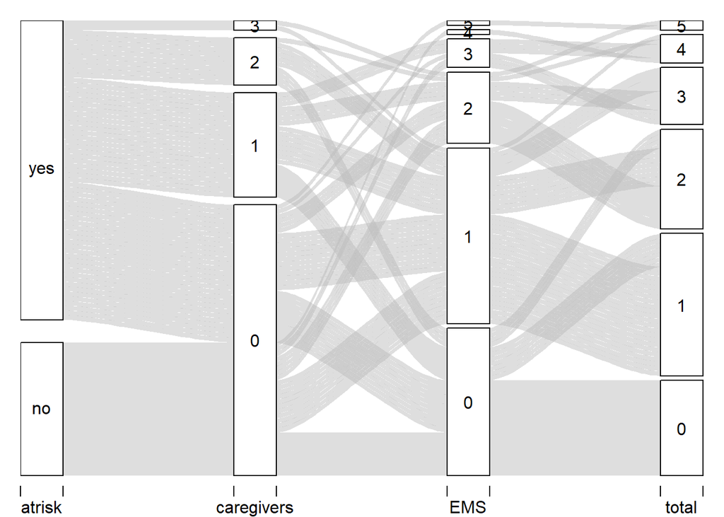

```r
# Create a database from pSERG with only the needed variables for the plots
alluvial <- pSERG[ , c("atrisk", "caregivers", "EMS", "total", "priorSE", "priorepilepsy")]

# Add the variable frequency of observations for the plots
alluvial$freq <- 91

# Change the name of the categories for the variable atrisk for the plots
alluvial$atrisk <- ifelse(alluvial$atrisk == "1", "yes", "no")

# Change the order of the variables of the database for the plots
alluvial <- alluvial[c("atrisk", "caregivers", "EMS", "total", "freq", "priorSE", "priorepilepsy")]



# Plot the diagrams:


# Diagram without color.
alluvial( alluvial[1:91,1:4], freq=alluvial$freq, border= NA, col= "gray")
```

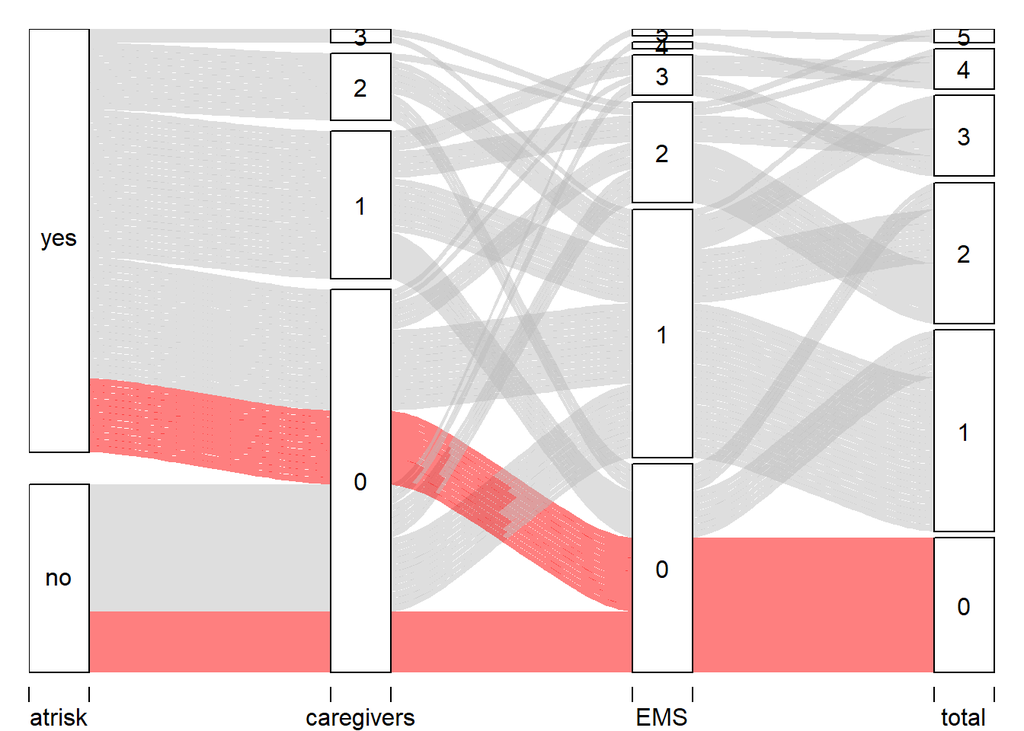

```r
# Red: patients who arrived to the hospital without treatment.
alluvial( alluvial[1:91,1:4], freq=alluvial$freq, border= NA,
              col=ifelse( alluvial$total == 0, "red", "gray"))
```

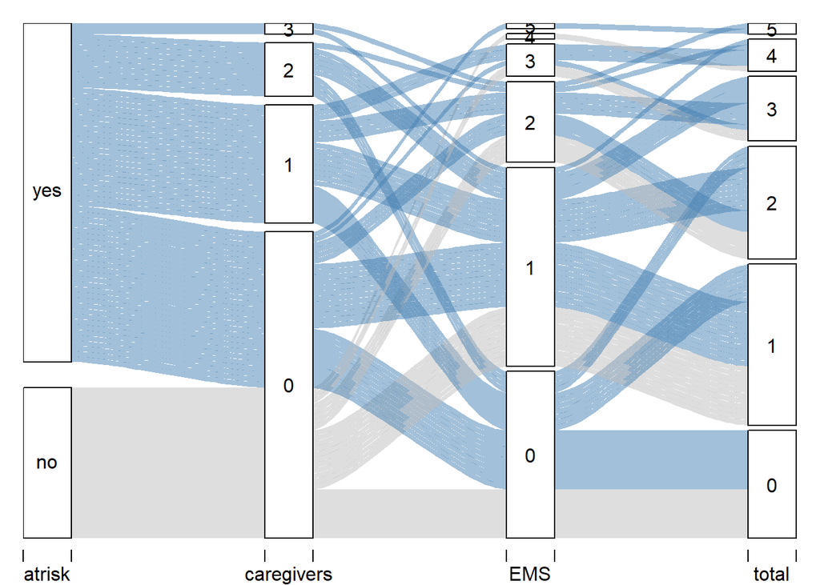

```r
# Blue: patients at risk.
alluvial( alluvial[1:91,1:4], freq=alluvial$freq, border=NA,
              col=ifelse( alluvial$atrisk == "yes", "Steelblue", "gray"))
```

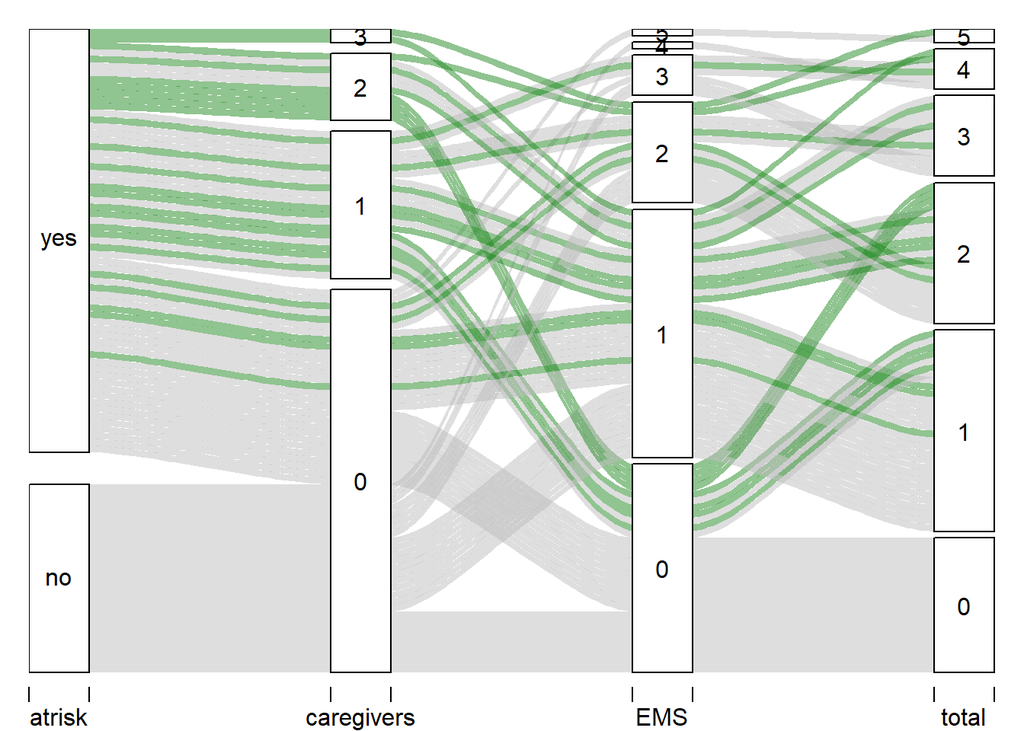

```r
# Green: patients with prior SE.
alluvial( alluvial[1:91,1:4], freq=alluvial$freq, border=NA,
              col=ifelse( alluvial$priorSE == 1, "forestgreen", "gray"))
```

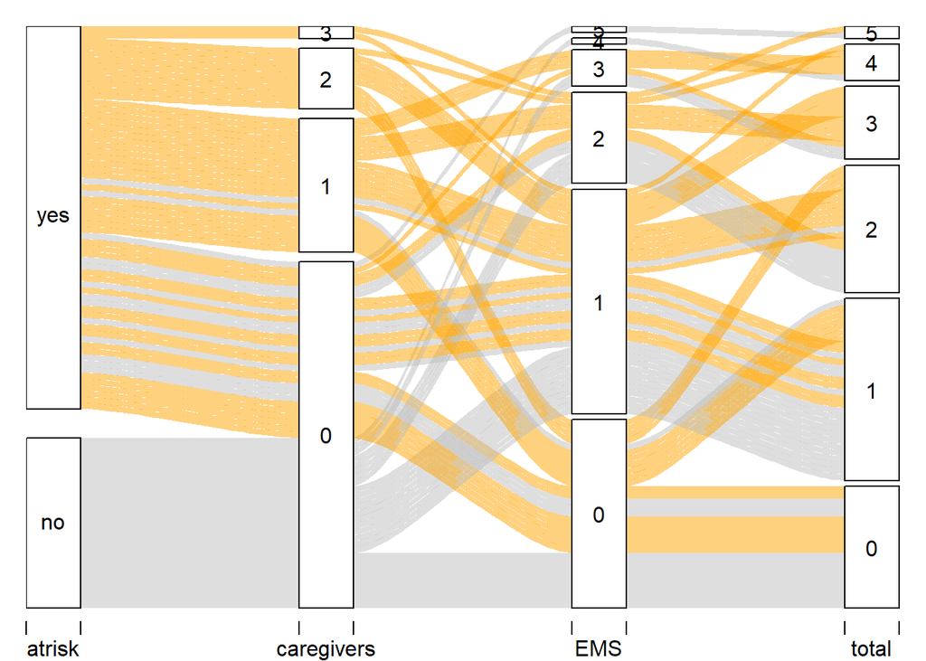

```r
# Orange: patients with prior epilepsy.
alluvial( alluvial[1:91,1:4], freq=alluvial$freq, border=NA,
              col=ifelse( alluvial$priorepilepsy == 1, "orange", "gray"))
```

TIME-TO-EVENT ANALYSES

## TIME TO FIRST BZD

```r
class(pSERG$BZDTIME.0)
```

```
## [1] "numeric"
```

```r
summary(pSERG$BZDTIME.0)
```

```
##    Min. 1st Qu.  Median    Mean 3rd Qu.    Max.
##    0.00    5.00   20.00   60.91   31.00 1605.00
```

```r
sd(pSERG$BZDTIME.0)
```

```
## [1] 207.6054
```

```r
# Create censtotal for the 1st BZD (1 if event before hospital arrival and within the first 60 min from SE onset, 0 censored).
pSERG$censh <- pSERG$HOSPITALARRIVAL - pSERG$BZDTIME.0
summary(pSERG$censh)
```

```
##     Min.  1st Qu.   Median     Mean  3rd Qu.     Max.
## -1535.00     2.00    19.00    11.83    38.00   845.00
```

```r
pSERG$censtotal <- ifelse(pSERG$censh > 0 & pSERG$BZDTIME.0 <= 60, 1, 0)
table(pSERG$censtotal)
```

```
##
##  0  1
## 26 65
```

```r
# Create variable time to event or censoring
pSERG$BZDtimeKM <- NA
pSERG$BZDtimeKM <- ifelse(pSERG$censtotal == 1, pSERG$BZDTIME.0, NA)
summary(pSERG$BZDtimeKM)
```

```
##    Min. 1st Qu.  Median    Mean 3rd Qu.    Max.    NA's
##    0.00    5.00   12.00   14.83   21.00   55.00      26
```

```r
pSERG$BZDtimeKM <- ifelse(pSERG$censtotal == 0 & pSERG$HOSPITALARRIVAL <= 60, pSERG$HOSPITALARRIVAL, pSERG$BZDtimeKM)
summary(pSERG$BZDtimeKM)
```

```
##    Min. 1st Qu.  Median    Mean 3rd Qu.    Max.    NA's
##    0.00    5.00   15.50   18.13   27.00   60.00       9
```

```r
pSERG$BZDtimeKM <- ifelse(pSERG$censtotal == 0 & pSERG$HOSPITALARRIVAL > 60, 60, pSERG$BZDtimeKM)
summary(pSERG$BZDtimeKM)
```

```
##    Min. 1st Qu.  Median    Mean 3rd Qu.    Max.
##    0.00    5.00   17.00   22.27   30.00   60.00
```

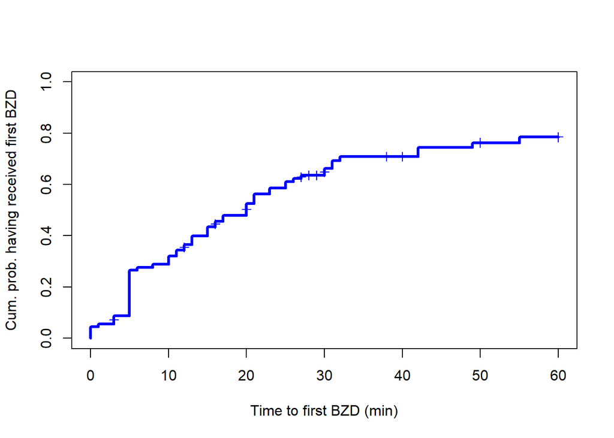

```r
# Figure time to first BZD (entire cohort)
plot(survfit(Surv(pSERG$BZDtimeKM, pSERG$censtotal) ~ 1), fun = "event",
     conf.int = FALSE, mark.time = TRUE, xlim = c(0, 60), ylim = c(0, 1), col = "blue", lwd = 3,
     cex.axis = 1, cex.lab = 1,
     xlab="Time to first BZD (min)", ylab="Cum. prob. having received first BZD")
```

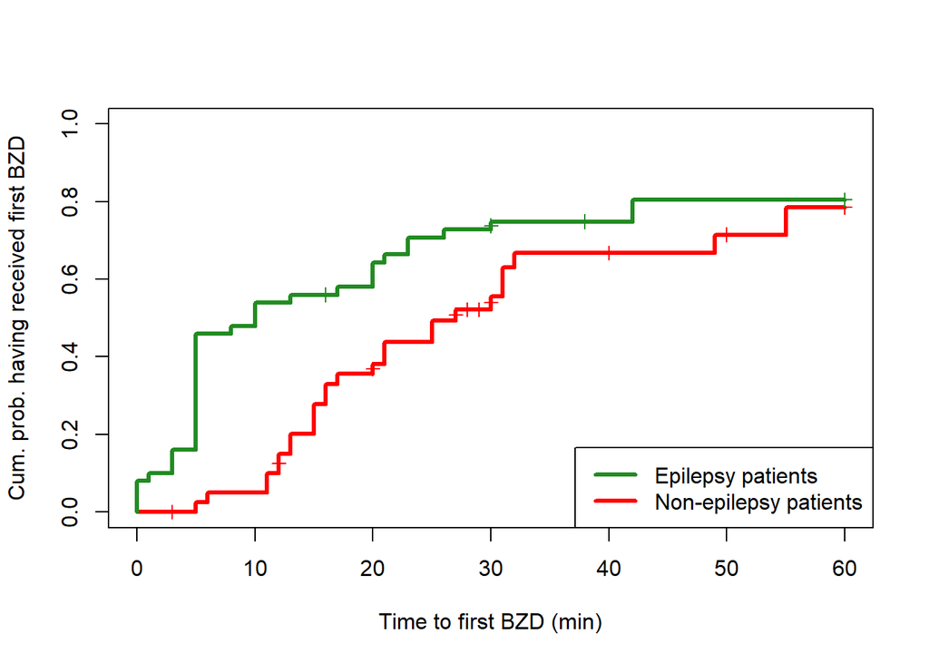

```r
# Figure time to first BZD by epilepsy patient group
plot(survfit(Surv(pSERG$BZDtimeKM, pSERG$censtotal) ~ pSERG$priorepilepsy), fun = "event",
     conf.int = FALSE, mark.time = TRUE, xlim = c(0, 60), ylim = c(0, 1), col = c("red", "forestgreen"), lwd = 3,
     cex.axis = 1, cex.lab = 1,
     xlab="Time to first BZD (min)", ylab="Cum. prob. having received first BZD")
legend(x = "bottomright", legend = c("Epilepsy patients", "Non-epilepsy patients"), col = c("forestgreen", "red"), lty = 1, lwd = 3)
```

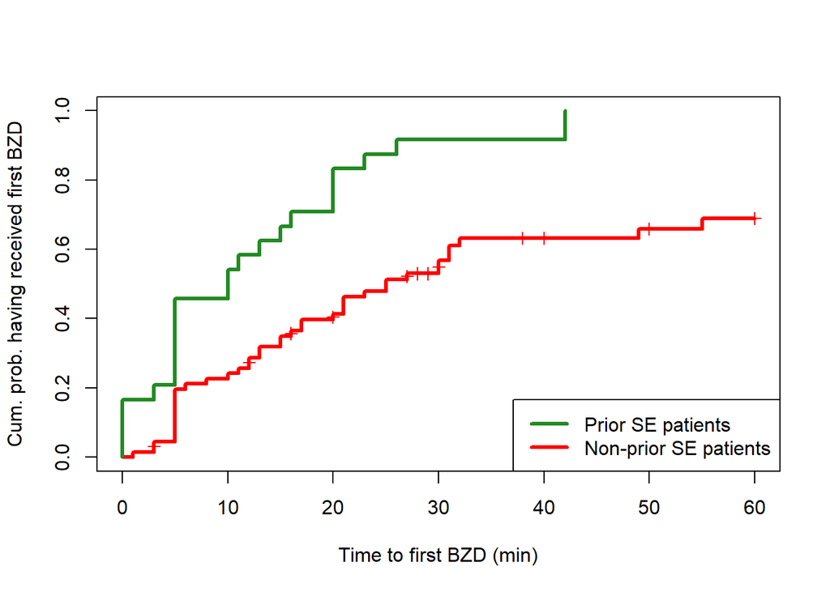

```r
# Figure time to first BZD by prior SE group
plot(survfit(Surv(pSERG$BZDtimeKM, pSERG$censtotal) ~ pSERG$priorSE), fun = "event",      conf.int = FALSE, mark.time = TRUE, xlim = c(0, 60), ylim = c(0, 1), col = c("red", "forestgreen"), lwd = 3,
     cex.axis = 1, cex.lab = 1,
     xlab="Time to first BZD (min)", ylab="Cum. prob. having received first BZD")
legend(x = "bottomright", legend = c("Prior SE patients", "Non-prior SE patients"), col = c("forestgreen", "red"), lty = 1, lwd = 3)
```

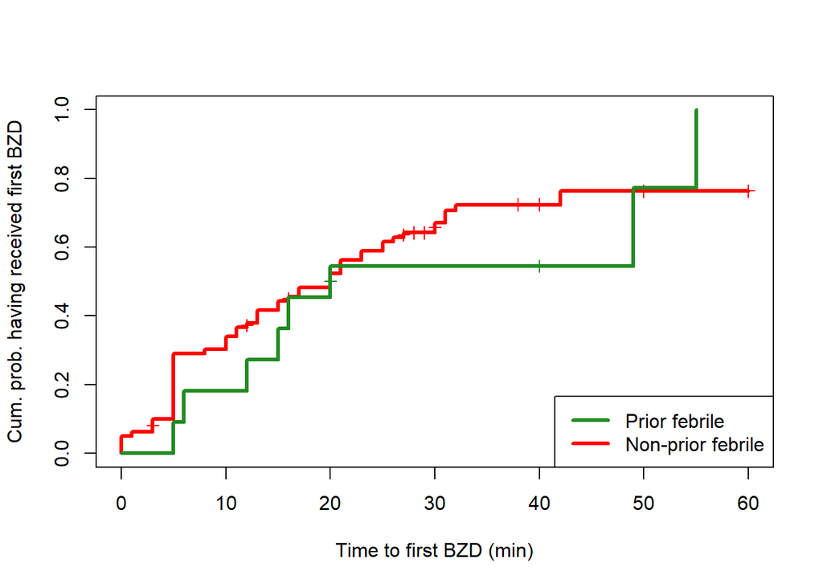

```r
# Figure time to first BZD by febrilesz group
plot(survfit(Surv(pSERG$BZDtimeKM, pSERG$censtotal) ~ pSERG$febrilesz), fun = "event",      conf.int = FALSE, mark.time = TRUE, xlim = c(0, 60), ylim = c(0, 1), col = c("red", "forestgreen"), lwd = 3,
     cex.axis = 1, cex.lab = 1,
     xlab="Time to first BZD (min)", ylab="Cum. prob. having received first BZD")
legend(x = "bottomright", legend = c("Prior febrile", "Non-prior febrile"), col = c("forestgreen", "red"), lty = 1, lwd = 3)
```

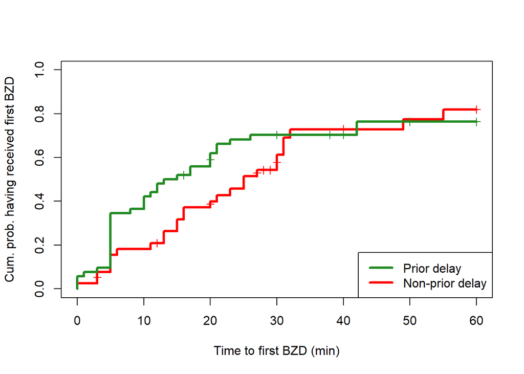

```r
# Figure time to first BZD by delay group
plot(survfit(Surv(pSERG$BZDtimeKM, pSERG$censtotal) ~ pSERG$delay), fun = "event",      conf.int = FALSE, mark.time = TRUE, xlim = c(0, 60), ylim = c(0, 1), col = c("red", "forestgreen"), lwd = 3,
     cex.axis = 1, cex.lab = 1,
     xlab="Time to first BZD (min)", ylab="Cum. prob. having received first BZD")
legend(x = "bottomright", legend = c("Prior delay", "Non-prior delay"), col = c("forestgreen", "red"), lty = 1, lwd = 3)
```

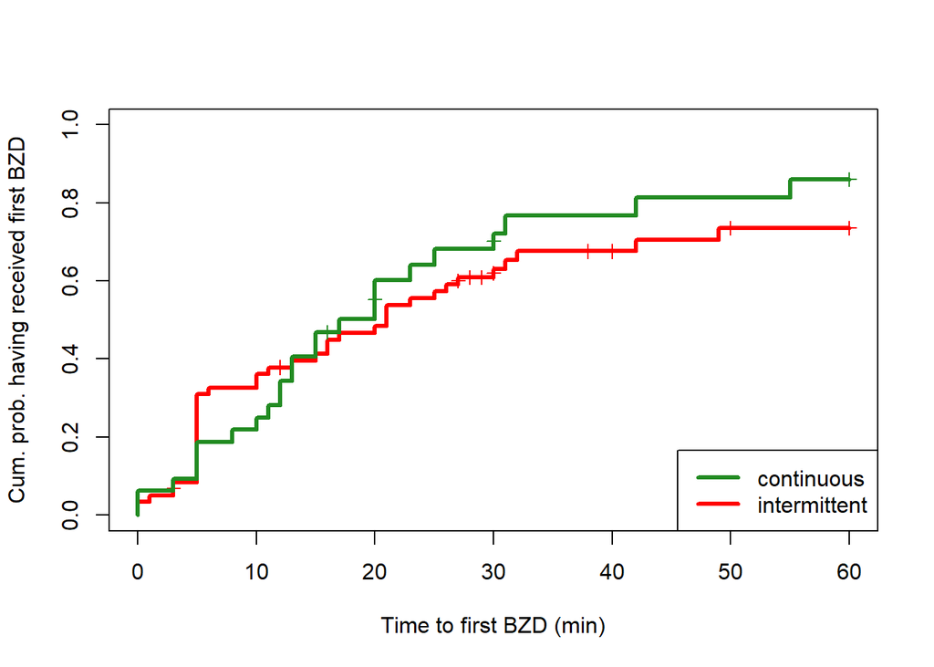

```r
# Figure time to first BZD by type SE group
plot(survfit(Surv(pSERG$BZDtimeKM, pSERG$censtotal) ~ pSERG$TYPESTATUS), fun = "event",      conf.int = FALSE, mark.time = TRUE, xlim = c(0, 60), ylim = c(0, 1), col = c("red", "forestgreen"), lwd = 3,
     cex.axis = 1, cex.lab = 1,
     xlab="Time to first BZD (min)", ylab="Cum. prob. having received first BZD")
legend(x = "bottomright", legend = c("continuous", "intermittent"), col = c("forestgreen", "red"), lty = 1, lwd = 3)
```

```r
#To compare two survival distributions (Gehan-Breslow-Wilcoxon test).
survdiff(Surv(pSERG$BZDtimeKM, pSERG$censtotal) ~ pSERG$priorepilepsy, rho = 1)
```

```
## Call:
## survdiff(formula = Surv(pSERG$BZDtimeKM, pSERG$censtotal) ~ pSERG$priorepilepsy,
##     rho = 1)
##
##                        N Observed Expected (O-E)^2/E (O-E)^2/V
## pSERG$priorepilepsy=0 41     13.6     22.6      3.63      11.3
## pSERG$priorepilepsy=1 50     29.8     20.7      3.98      11.3
##
##  Chisq= 11.3  on 1 degrees of freedom, p= 8e-04
```

```r
survdiff(Surv(pSERG$BZDtimeKM, pSERG$censtotal) ~ pSERG$priorSE, rho = 1)
```

```
## Call:
## survdiff(formula = Surv(pSERG$BZDtimeKM, pSERG$censtotal) ~ pSERG$priorSE,
##     rho = 1)
##
##                  N Observed Expected (O-E)^2/E (O-E)^2/V
## pSERG$priorSE=0 67     26.0    34.91      2.26      16.5
## pSERG$priorSE=1 24     17.3     8.41      9.37      16.5
##
##  Chisq= 16.5  on 1 degrees of freedom, p= 5e-05
```

```r
survdiff(Surv(pSERG$BZDtimeKM, pSERG$censtotal) ~ pSERG$delay, rho = 1)
```

```
## Call:
## survdiff(formula = Surv(pSERG$BZDtimeKM, pSERG$censtotal) ~ pSERG$delay,
##     rho = 1)
##
##                N Observed Expected (O-E)^2/E (O-E)^2/V
## pSERG$delay=0 39     15.5     20.1     1.068      2.96
## pSERG$delay=1 52     27.8     23.2     0.925      2.96
##
##  Chisq= 3  on 1 degrees of freedom, p= 0.09
```

```r
survdiff(Surv(pSERG$BZDtimeKM, pSERG$censtotal) ~ pSERG$TYPESTATUS, rho = 1)
```

```
## Call:
## survdiff(formula = Surv(pSERG$BZDtimeKM, pSERG$censtotal) ~ pSERG$TYPESTATUS,
##     rho = 1)
##
##                     N Observed Expected (O-E)^2/E (O-E)^2/V
## pSERG$TYPESTATUS=0 59     27.6     28.3    0.0209    0.0888
## pSERG$TYPESTATUS=1 32     15.8     15.0    0.0396    0.0888
##
##  Chisq= 0.1  on 1 degrees of freedom, p= 0.8
```

```r
survdiff(Surv(pSERG$BZDtimeKM, pSERG$censtotal) ~ pSERG$febrilesz, rho = 1)
```

```
## Call:
## survdiff(formula = Surv(pSERG$BZDtimeKM, pSERG$censtotal) ~ pSERG$febrilesz,
##     rho = 1)
##
##                    N Observed Expected (O-E)^2/E (O-E)^2/V
## pSERG$febrilesz=0 80    38.85    37.69    0.0352     0.397
## pSERG$febrilesz=1 11     4.48     5.63    0.2357     0.397
##
##  Chisq= 0.4  on 1 degrees of freedom, p= 0.5
```

```r
# Test proportional hazards assumption (create the zph object):
time.dep.zphBZD <- cox.zph(coxph(Surv(pSERG$BZDtimeKM, pSERG$censtotal) ~pSERG$priorepilepsy+pSERG$ageyears+pSERG$febrilesz+pSERG$delay+pSERG$TYPESTATUS+pSERG$priorSE))
time.dep.zphBZD
```

```
##                         rho  chisq        p
## pSERG$priorepilepsy -0.4044 11.066 0.000879
## pSERG$ageyears       0.1124  0.914 0.339033
## pSERG$febrilesz     -0.0575  0.211 0.645603
## pSERG$delay         -0.1441  1.406 0.235753
## pSERG$TYPESTATUS     0.1790  2.298 0.129535
## pSERG$priorSE        0.1913  2.943 0.086224
## GLOBAL                   NA 22.092 0.001165
```

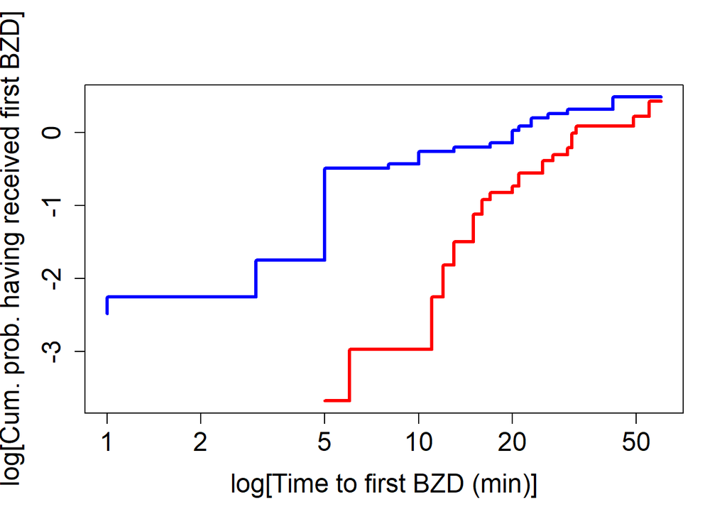

```r
# Proportional hazards assumption for priorepilepsy and plot residual
plot(survfit(Surv(pSERG$BZDtimeKM, pSERG$censtotal) ~ pSERG$priorepilepsy), fun = "cloglog",
 conf.int=FALSE, col = c("red", "blue"), lwd = 3,
 cex.axis = 1.5, cex.lab = 1.5,
 xlab="log[Time to first BZD (min)]", ylab="log[Cum. prob. having received first BZD]")
```

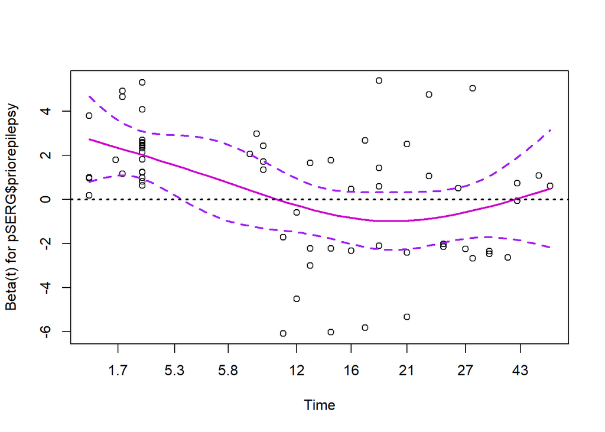

```r
plot(time.dep.zphBZD[1],
 lwd = 2,
 col = c("magenta3", "purple"))
abline(h=0, lty = 3, lwd = 2)
```

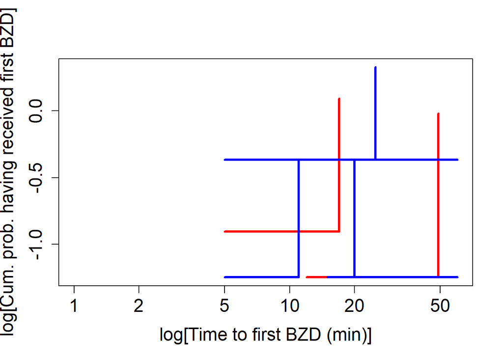

```r
# Proportional hazards assumption for ageyears and plot residual
plot(survfit(Surv(pSERG$BZDtimeKM, pSERG$censtotal) ~ pSERG$ageyears), fun = "cloglog",
 conf.int=FALSE, col = c("red", "blue"), lwd = 3,
 cex.axis = 1.5, cex.lab = 1.5,
 xlab="log[Time to first BZD (min)]", ylab="log[Cum. prob. having received first BZD]")
```

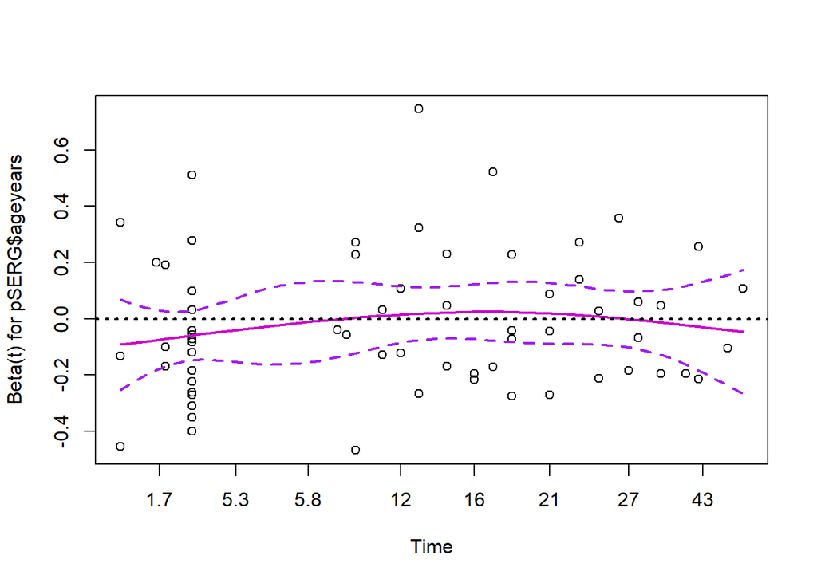

```r
plot(time.dep.zphBZD[2],
 lwd = 2,
 col = c("magenta3", "purple"))
abline(h=0, lty = 3, lwd = 2)
```

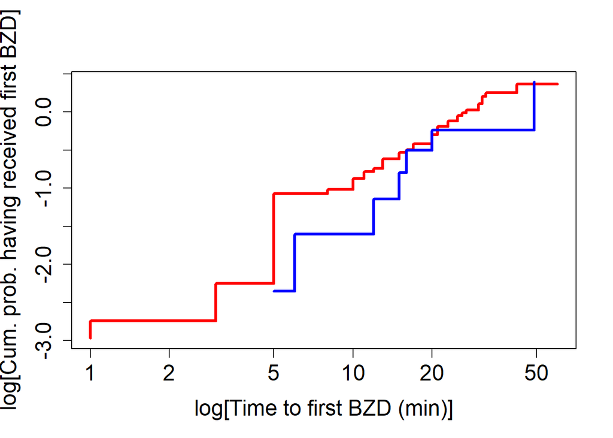

```r
# Proportional hazards assumption for febrile and plot residual
plot(survfit(Surv(pSERG$BZDtimeKM, pSERG$censtotal) ~ pSERG$febrilesz), fun = "cloglog",
 conf.int=FALSE, col = c("red", "blue"), lwd = 3,
 cex.axis = 1.5, cex.lab = 1.5,
 xlab="log[Time to first BZD (min)]", ylab="log[Cum. prob. having received first BZD]")
```

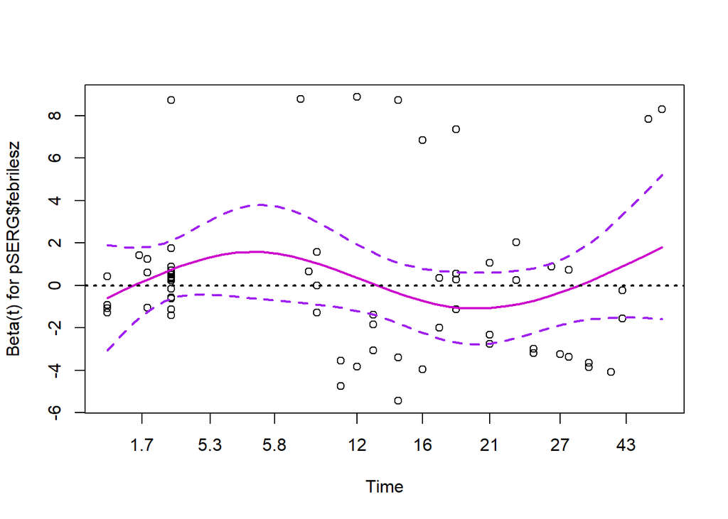

```r
plot(time.dep.zphBZD[3],
 lwd = 2,
 col = c("magenta3", "purple"))
abline(h=0, lty = 3, lwd = 2)
```

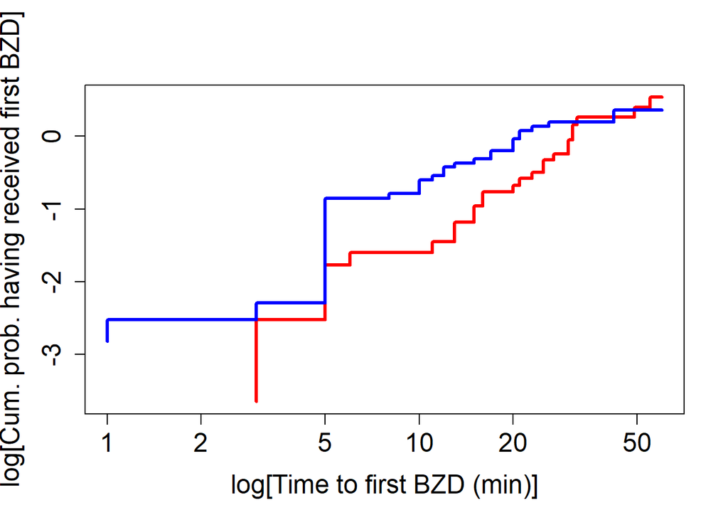

```r
# Proportional hazards assumption for delay and plot residual
plot(survfit(Surv(pSERG$BZDtimeKM, pSERG$censtotal) ~ pSERG$delay), fun = "cloglog",
 conf.int=FALSE, col = c("red", "blue"), lwd = 3,
 cex.axis = 1.5, cex.lab = 1.5,
 xlab="log[Time to first BZD (min)]", ylab="log[Cum. prob. having received first BZD]")
```

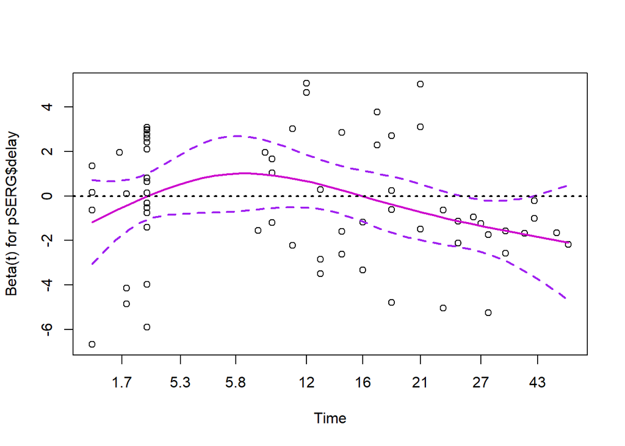

```r
plot(time.dep.zphBZD[4],
 lwd = 2,
 col = c("magenta3", "purple"))
abline(h=0, lty = 3, lwd = 2)
```

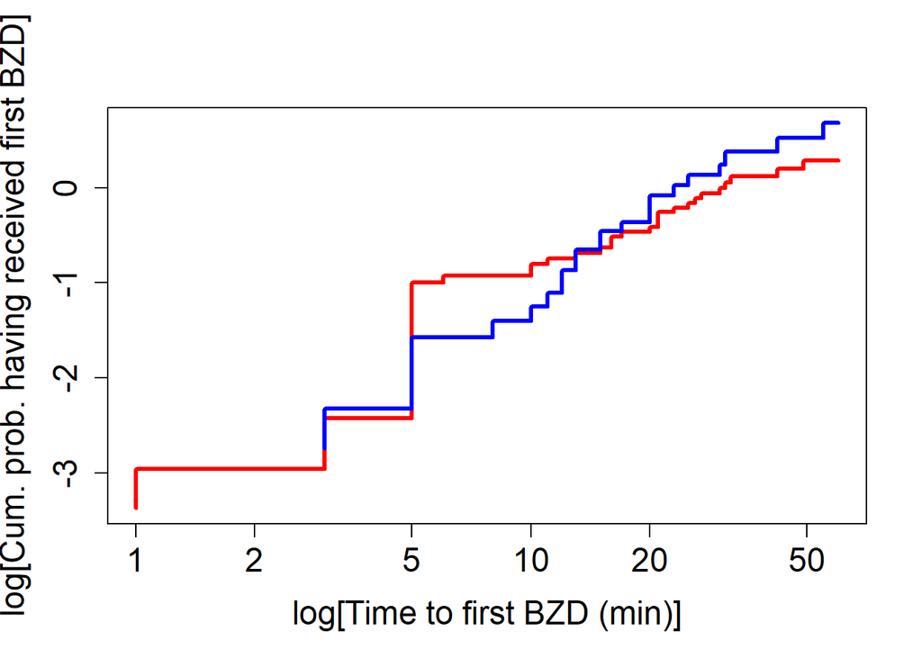

```r
# Proportional hazards assumption for TYPESTATUS and plot residual
plot(survfit(Surv(pSERG$BZDtimeKM, pSERG$censtotal) ~ pSERG$TYPESTATUS), fun = "cloglog",
 conf.int=FALSE, col = c("red", "blue"), lwd = 3,
 cex.axis = 1.5, cex.lab = 1.5,
 xlab="log[Time to first BZD (min)]", ylab="log[Cum. prob. having received first BZD]")
```

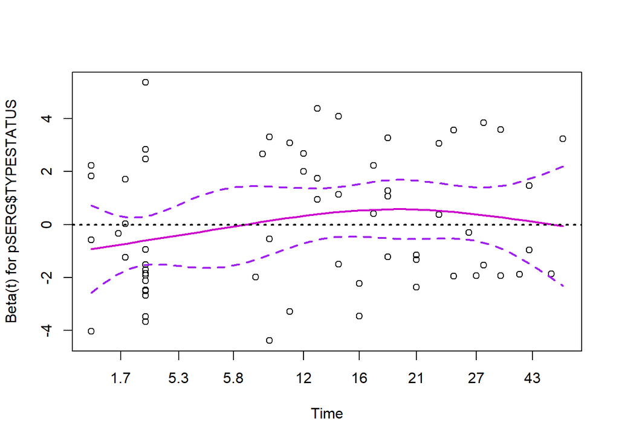

```r
plot(time.dep.zphBZD[5],
 lwd = 2,
 col = c("magenta3", "purple"))
abline(h=0, lty = 3, lwd = 2)
```

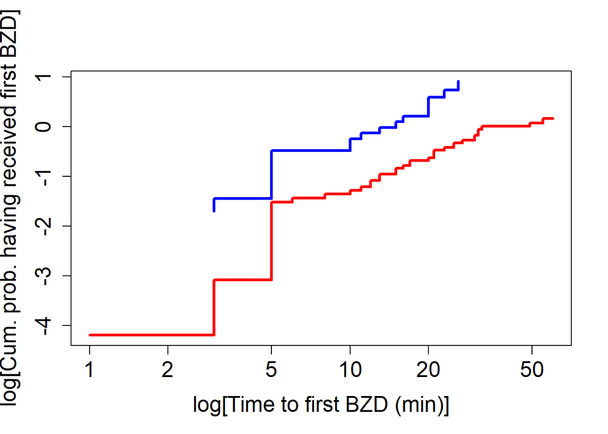

```r
# Proportional hazards assumption for priorSE and plot residual
plot(survfit(Surv(pSERG$BZDtimeKM, pSERG$censtotal) ~ pSERG$priorSE), fun = "cloglog",
 conf.int=FALSE, col = c("red", "blue"), lwd = 3,
 cex.axis = 1.5, cex.lab = 1.5,
 xlab="log[Time to first BZD (min)]", ylab="log[Cum. prob. having received first BZD]")
```

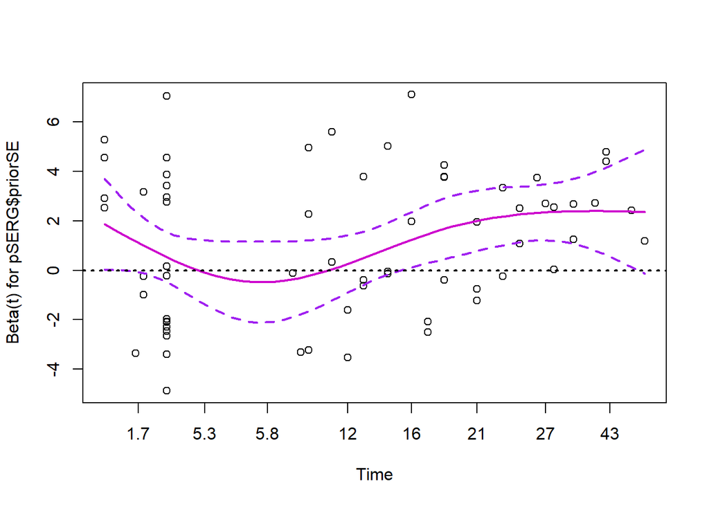

```r
plot(time.dep.zphBZD[6],
 lwd = 2,
 col = c("magenta3", "purple"))
abline(h=0, lty = 3, lwd = 2)
```

```r
# Cox proportional hazards regression model for multiple predictors.
summary(coxph(Surv(pSERG$BZDtimeKM, pSERG$censtotal) ~pSERG$ageyears+pSERG$febrilesz+pSERG$delay+pSERG$TYPESTATUS+pSERG$priorSE+pSERG$priorepilepsy))
```

```
## Call:
## coxph(formula = Surv(pSERG$BZDtimeKM, pSERG$censtotal) ~ pSERG$ageyears +
##     pSERG$febrilesz + pSERG$delay + pSERG$TYPESTATUS + pSERG$priorSE +
##     pSERG$priorepilepsy)
##
##   n= 91, number of events= 65
##
##                         coef exp(coef) se(coef)      z Pr(>|z|)
## pSERG$ageyears      -0.02046   0.97975  0.02830 -0.723 0.469769
## pSERG$febrilesz      0.12908   1.13778  0.43753  0.295 0.767985
## pSERG$delay         -0.35984   0.69779  0.33165 -1.085 0.277925
## pSERG$TYPESTATUS    -0.01850   0.98167  0.28986 -0.064 0.949116
## pSERG$priorSE        1.17813   3.24830  0.32279  3.650 0.000262 ***
## pSERG$priorepilepsy  0.52733   1.69441  0.34049  1.549 0.121441
## ---
## Signif. codes:  0 '***' 0.001 '**' 0.01 '*' 0.05 '.' 0.1 ' ' 1
##
##                     exp(coef) exp(-coef) lower .95 upper .95
## pSERG$ageyears         0.9798     1.0207    0.9269     1.036
## pSERG$febrilesz        1.1378     0.8789    0.4826     2.682
## pSERG$delay            0.6978     1.4331    0.3643     1.337
## pSERG$TYPESTATUS       0.9817     1.0187    0.5562     1.733
## pSERG$priorSE          3.2483     0.3079    1.7254     6.115
## pSERG$priorepilepsy    1.6944     0.5902    0.8693     3.302
##
## Concordance= 0.665  (se = 0.043 )
## Rsquare= 0.193   (max possible= 0.996 )
## Likelihood ratio test= 19.55  on 6 df,   p=0.003
## Wald test            = 21.14  on 6 df,   p=0.002
## Score (logrank) test = 23.15  on 6 df,   p=7e-04
```

```r
# Univariate Cox regression model with ageyears and prior epilepsy:
summary(coxph(Surv(pSERG$BZDtimeKM, pSERG$censtotal)~pSERG$ageyears))
```

```
## Call:
## coxph(formula = Surv(pSERG$BZDtimeKM, pSERG$censtotal) ~ pSERG$ageyears)
##
##   n= 91, number of events= 65
##
##                    coef exp(coef) se(coef)     z Pr(>|z|)
## pSERG$ageyears 0.008716  1.008755 0.023340 0.373    0.709
##
##                exp(coef) exp(-coef) lower .95 upper .95
## pSERG$ageyears     1.009     0.9913    0.9636     1.056
##
## Concordance= 0.537  (se = 0.043 )
## Rsquare= 0.002   (max possible= 0.996 )
## Likelihood ratio test= 0.14  on 1 df,   p=0.7
## Wald test            = 0.14  on 1 df,   p=0.7
## Score (logrank) test = 0.14  on 1 df,   p=0.7
```

```r
summary(coxph(Surv(pSERG$BZDtimeKM, pSERG$censtotal)~pSERG$priorepilepsy))
```

```
## Call:
## coxph(formula = Surv(pSERG$BZDtimeKM, pSERG$censtotal) ~ pSERG$priorepilepsy)
##
##   n= 91, number of events= 65
##
##                       coef exp(coef) se(coef)     z Pr(>|z|)
## pSERG$priorepilepsy 0.5766    1.7800   0.2544 2.266   0.0234 *
## ---
## Signif. codes:  0 '***' 0.001 '**' 0.01 '*' 0.05 '.' 0.1 ' ' 1
##
##                     exp(coef) exp(-coef) lower .95 upper .95
## pSERG$priorepilepsy      1.78     0.5618     1.081     2.931
##
## Concordance= 0.622  (se = 0.037 )
## Rsquare= 0.056   (max possible= 0.996 )
## Likelihood ratio test= 5.26  on 1 df,   p=0.02
## Wald test            = 5.14  on 1 df,   p=0.02
## Score (logrank) test = 5.28  on 1 df,   p=0.02
```

```r
# Check collinearity
#install.packages("performance")

library(performance)

check_collinearity(coxph(Surv(BZDtimeKM, censtotal) ~ageyears+febrilesz+delay+TYPESTATUS+priorSE+priorepilepsy, data=pSERG))
```

```
## # Check for Multicollinearity
##
## Low Correlation
##
##           Term  VIF Increased SE Tolerance
##      febrilesz 1.25         1.12      0.80
##          delay 1.50         1.22      0.67
##     TYPESTATUS 1.14         1.07      0.88
##        priorSE 1.36         1.17      0.74
##  priorepilepsy 1.58         1.26      0.63
```

```r
cor(pSERG$priorSE, pSERG$priorepilepsy)
```

```
## [1] 0.3414851
```

## TIME TO FIRST NON-BZD ASM

```r
# Create censtotal2 for non-BZD ASM (1 if event before hospital arrival and within the first 60 min from SE onset, 0 censored).
pSERG$censh2 <- pSERG$HOSPITALARRIVAL - pSERG$AEDTIME.0
summary(pSERG$censh2)
```

```
##     Min.  1st Qu.   Median     Mean  3rd Qu.     Max.
## -1365.00   -48.50   -30.00   -66.19   -13.00     0.00
```

```r
pSERG$censtotal2 <- ifelse(pSERG$censh2 > 0 & pSERG$AEDTIME.0 <= 60, 1, 0)
table(pSERG$censtotal2)
```

```
##
##  0
## 91
```

```r
# create variable time to event or censoring
pSERG$AEDtimeKM <- NA
pSERG$AEDtimeKM <- ifelse(pSERG$censtotal2 == 1, pSERG$AEDTIME.0, NA)
pSERG$AEDtimeKM <- ifelse(pSERG$censtotal2 == 0 & pSERG$censh2 <= 0 & pSERG$HOSPITALARRIVAL <= 60, pSERG$HOSPITALARRIVAL, pSERG$AEDtimeKM)
pSERG$AEDtimeKM <- ifelse(pSERG$censtotal2 == 0 & pSERG$censh2 <= 0 & pSERG$HOSPITALARRIVAL > 60, 60, pSERG$AEDtimeKM)
summary(pSERG$AEDtimeKM)
```

```
##    Min. 1st Qu.  Median    Mean 3rd Qu.    Max.
##    3.00   29.50   45.00   42.14   60.00   60.00
```

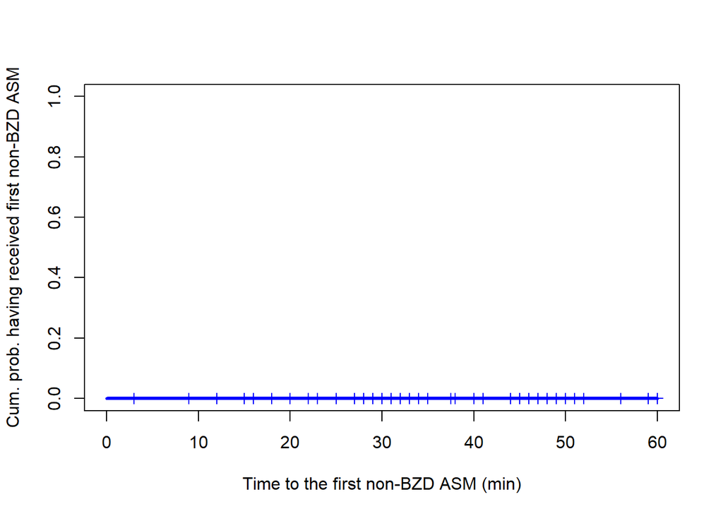

```r
# Figure time to first non-BZD ASM (entire cohort)
plot(survfit(Surv(pSERG$AEDtimeKM, pSERG$censtotal2) ~ 1), fun = "event",
     conf.int = FALSE, mark.time = TRUE, xlim = c(0, 60), ylim = c(0, 1), col = "blue", lwd = 3,
     cex.axis = 1, cex.lab = 1,
     xlab="Time to the first non-BZD ASM (min)", ylab="Cum. prob. having received first non-BZD ASM")
```

## CAREGIVERS’ PERFORMANCE IN AT-RISK PATIENTS (EPILEPSY, FEBRILE SZ, PRIOR SE)

```r
# Create censadmin for first BZD (1 if event before EMS arrival and within the first 30 min from seizure onset, 0 censored)
pSERG$censc <- pSERG$EMSARRIVAL - pSERG$BZDTIME.0
summary(pSERG$censc)
```

```
##     Min.  1st Qu.   Median     Mean  3rd Qu.     Max.
## -1581.00   -11.50    -2.00   -15.34     9.50   784.00
```

```r
pSERG$censadmin2 <- ifelse(pSERG$censc > 0 & pSERG$BZDTIME.0 <= 30, 1, 0)
table(pSERG$censadmin2)
```

```
##
##  0  1
## 60 31
```

```r
# Create variable time to event or censoring
pSERG$BZDcaregiver <- NA
pSERG$BZDcaregiver <- ifelse(pSERG$censadmin2 == 1, pSERG$BZDTIME.0, NA)
pSERG$BZDcaregiver <- ifelse(pSERG$censadmin2 == 0 & pSERG$EMSARRIVAL <= 30, pSERG$EMSARRIVAL, pSERG$BZDcaregiver)
pSERG$BZDcaregiver <- ifelse(pSERG$censadmin2 == 0 & pSERG$EMSARRIVAL > 30, 30, pSERG$BZDcaregiver)
summary(pSERG$BZDcaregiver)
```

```
##    Min. 1st Qu.  Median    Mean 3rd Qu.    Max.
##    0.00    5.00   10.00   13.36   20.00   30.00
```

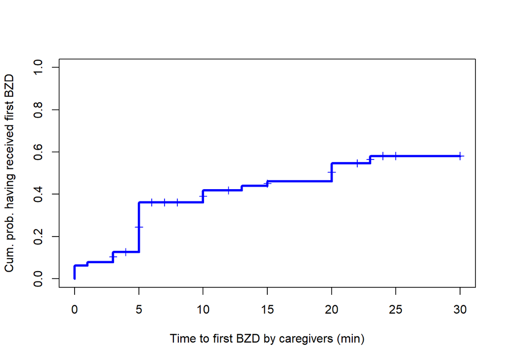

```r
# Figure time to first BZD by caregivers in at-risk patients (all at-risk patients)
plot(survfit(Surv(pSERG[which(pSERG$atrisk== 1),]$BZDcaregiver, pSERG[which(pSERG$atrisk== 1),]$censadmin2) ~ 1), fun = "event",
     conf.int = FALSE, mark.time = TRUE, xlim = c(0, 30), ylim = c(0, 1), col = "blue", lwd = 3,
     cex.axis = 1, cex.lab = 1,
     xlab="Time to first BZD by caregivers (min)", ylab="Cum. prob. having received first BZD")
```

```r
# Test proportional hazards assumption (create the zph object):
time.dep.zphBZDatrisk <- cox.zph(coxph(Surv(pSERG[which(pSERG$atrisk== 1),]$BZDcaregiver, pSERG[which(pSERG$atrisk== 1),]$censadmin2) ~
                pSERG[which(pSERG$atrisk== 1),]$ageyears+
                pSERG[which(pSERG$atrisk== 1),]$delay+
                pSERG[which(pSERG$atrisk== 1),]$TYPESTATUS+
                pSERG[which(pSERG$atrisk== 1),]$priorSE))
time.dep.zphBZDatrisk
```

```
##                                                  rho  chisq     p
## pSERG[which(pSERG$atrisk == 1), ]$ageyears   -0.0771 0.2023 0.653
## pSERG[which(pSERG$atrisk == 1), ]$delay       0.0550 0.0948 0.758
## pSERG[which(pSERG$atrisk == 1), ]$TYPESTATUS  0.2384 1.8899 0.169
## pSERG[which(pSERG$atrisk == 1), ]$priorSE     0.2157 1.6167 0.204
## GLOBAL                                            NA 6.1666 0.187
```

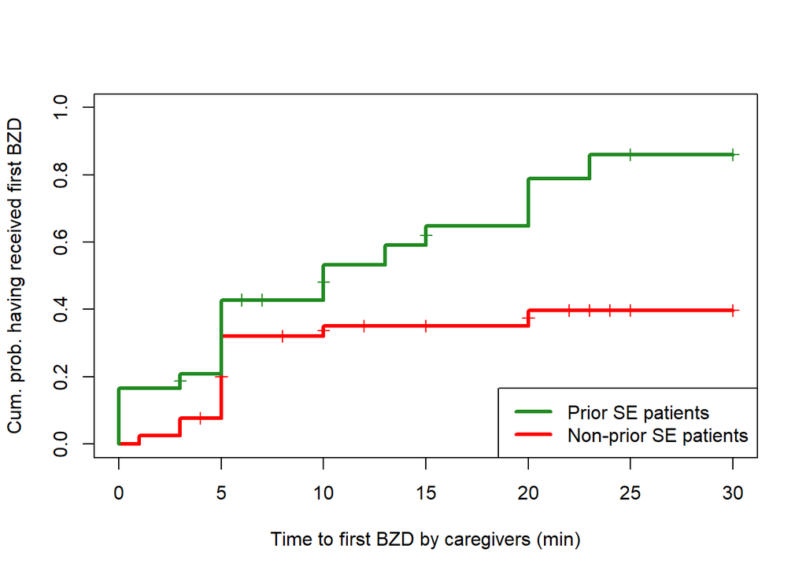

```r
# Figure time to first BZD in at-risk patients by caregivers, prior SE / non-prior SE group
plot(survfit(Surv(pSERG[which(pSERG$atrisk== 1),]$BZDcaregiver, pSERG[which(pSERG$atrisk== 1),]$censadmin2) ~ pSERG[which(pSERG$atrisk== 1),]$priorSE), fun = "event",  conf.int = FALSE, mark.time = TRUE, xlim = c(0, 30), ylim = c(0, 1), col = c("red", "forestgreen"), lwd = 3,
     cex.axis = 1, cex.lab = 1,
     xlab="Time to first BZD by caregivers (min)", ylab="Cum. prob. having received first BZD")
legend(x = "bottomright", legend = c("Prior SE patients", "Non-prior SE patients"), col = c("forestgreen", "red"), lty = 1, lwd = 3)
```

```r
#To compare two survival distributions.
survdiff(Surv(pSERG[which(pSERG$atrisk== 1),]$BZDcaregiver, pSERG[which(pSERG$atrisk== 1),]$censadmin2) ~ pSERG[which(pSERG$atrisk== 1),]$priorSE, rho = 1)
```

```
## Call:
## survdiff(formula = Surv(pSERG[which(pSERG$atrisk == 1), ]$BZDcaregiver,
##     pSERG[which(pSERG$atrisk == 1), ]$censadmin2) ~ pSERG[which(pSERG$atrisk ==
##     1), ]$priorSE, rho = 1)
##
##                                              N Observed Expected (O-E)^2/E
## pSERG[which(pSERG$atrisk == 1), ]$priorSE=0 39     11.8     16.5      1.36
## pSERG[which(pSERG$atrisk == 1), ]$priorSE=1 24     13.2      8.5      2.64
##                                             (O-E)^2/V
## pSERG[which(pSERG$atrisk == 1), ]$priorSE=0      5.59
## pSERG[which(pSERG$atrisk == 1), ]$priorSE=1      5.59
##
##  Chisq= 5.6  on 1 degrees of freedom, p= 0.02
```

## Other calculations

```r
# Patients for the main outcome
table(pSERG$HOSPITALARRIVAL > 39, pSERG$HOSPITALARRIVAL < 40)
```

```
##
##         FALSE TRUE
##   FALSE     0   38
##   TRUE     53    0
```

```r
pSERG[which(pSERG$HOSPITALARRIVAL < 40 & pSERG$BZDTIME.0 < 10), "prehospital"]
```

```
##  [1]  6  2  1  1  6  6  7 11  3  6  7  1
```

```r
# Patients who did not receive any BZD by caregivers and had a prior diagnosis of epilepsy.
table(pSERG[which(pSERG$caregivers == "0"),]$priorepilepsy)
```

```
##
##  0  1
## 39 18
```

```r
table(pSERG[which(pSERG$priorepilepsy == "1"),]$caregivers)
```

```
##
##  0  1  2  3
## 18 20 10  2
```

```r
# Patients who did not receive any BZD by caregivers and had a prior SE.
table(pSERG[which(pSERG$caregivers == "0"),]$priorSE)
```

```
##
##  0  1
## 52  5
```

```r
table(pSERG[which(pSERG$priorSE == "1"),]$caregivers)
```

```
##
##  0  1  2  3
##  5 10  7  2
```

```r
# Patients who did not receive any BZD by caregivers and had febrile sz.
table(pSERG[which(pSERG$caregivers == "0"),]$febrilesz)
```

```
##
##  0  1
## 47 10
```

```r
table(pSERG[which(pSERG$febrilesz == "1"),]$caregivers)
```

```
##
##  0  1
## 10  1
```

```r
# Patients who did not receive any BZD by caregivers and were at-risk patients.
table(pSERG[which(pSERG$caregivers == "0"),]$atrisk)
```

```
##
##  0  1
## 28 29
```

```r
table(pSERG[which(pSERG$atrisk == "1"),]$caregivers)
```

```
##
##  0  1  2  3
## 29 22 10  2
```

```r
# At-risk patients and prehospital variable.
table(pSERG[which(pSERG$atrisk == "1"),]$prehospital)
```

```
##
##  0  1  2  3  5  6  7  8  9 10 11 12 14 15
## 11 12  4  1  1  7  8  4  3  4  5  1  1  1
```

## Preparing KM for publications (inclusion of numbers at risk and cumulative censored)

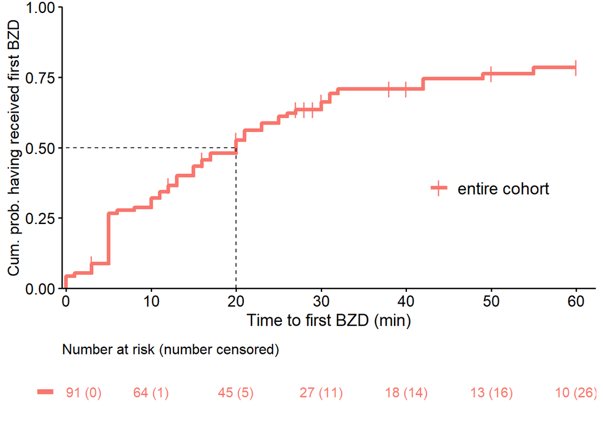

```r
# BZD ---------------------

### Entire cohort


ent <- survfit(Surv(pSERG$BZDtimeKM, pSERG$censtotal) ~ 1)

entgeneral <- ggsurvplot(ent, data = pSERG, fun = "event", censor = TRUE, censor.shape="|", censor.size=4.5,
     conf.int = FALSE, risk.table = "nrisk_cumcensor", tables.theme = theme_cleantable() , surv.median.line = "hv",  xlim = c(-0.5, 62.3), ylim = c(0, 1), axes.offset=FALSE, break.y.by=0.25, break.x.by=10, tables.col="strata",   risk.table.pos="out", risk.table.fontsize=4, risk.table.y.text= F, legend = c(0.8, 0.4), legend.title="", font.x = c(14, "plain", "black"), font.y = c(13, "plain", "black"), font.tickslab=c(13, "plain", "black"), font.legend=c(14),  surv.plot.height = 0.78, risk.table.height=0.22, size=1.5,
               legend.labs=c("entire cohort"),
     xlab="Time to first BZD (min)", ylab="Cum. prob. having received first BZD")

entgeneral$table <- entgeneral$table +
  theme(plot.title = element_text(size = 12, color = "black", face = "plain"))

entgeneral
```

[figure not shown]

```r
### With epilepsy or not

ep <- survfit(Surv(pSERG$BZDtimeKM, pSERG$censtotal) ~ pSERG$priorepilepsy)

epigeneral <- ggsurvplot(ep, data = pSERG, fun = "event", censor = TRUE, censor.shape="|", censor.size=4.5,
     conf.int = FALSE, pval="p < 0.001", pval.coord=c(10, 0.8), pval.size=4, risk.table = "nrisk_cumcensor", tables.theme = theme_cleantable() , surv.median.line = "hv",  xlim = c(-0.5, 62), ylim = c(-0.010, 1), axes.offset=FALSE, break.y.by=0.25, break.x.by=10, tables.col="strata",   risk.table.pos="out", risk.table.fontsize=4, risk.table.y.text= F, legend = c(0.8, 0.4), legend.title="", font.x = c(14, "plain", "black"), font.y = c(13, "plain", "black"), font.tickslab=c(13, "plain", "black"), font.legend=c(14),  surv.plot.height = 0.78, risk.table.height=0.22, size=1.5,
               legend.labs=c("non-epilepsy patients", "epilepsy patients"),
     xlab="Time to first BZD (min)", ylab="Cum. prob. having received first BZD")
epigeneral$table <- epigeneral$table +
  theme(plot.title = element_text(size = 12, color = "black", face = "plain"))

epigeneral
```

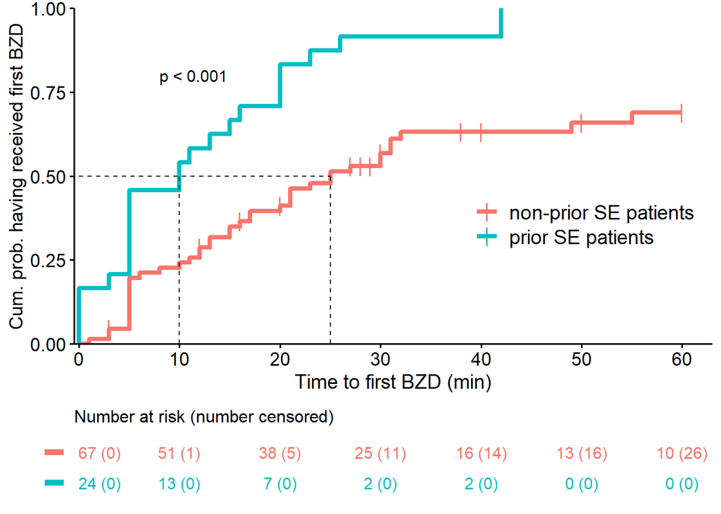

```r
### With SE or not

SE <- survfit(Surv(pSERG$BZDtimeKM, pSERG$censtotal) ~ pSERG$priorSE)

SEgeneral <- ggsurvplot(SE, data = pSERG, fun = "event", censor = TRUE, censor.shape="|", censor.size=4.5,
     conf.int = FALSE, pval= "p < 0.001", pval.coord=c(8, 0.8), pval.size=4, risk.table = "nrisk_cumcensor", tables.theme = theme_cleantable() , surv.median.line = "hv",  xlim = c(-0.5, 63), ylim = c(0, 1), axes.offset=FALSE, break.y.by=0.25, break.x.by=10, tables.col="strata",   risk.table.pos="out", risk.table.fontsize=4, risk.table.y.text= F, legend = c(0.8, 0.4), legend.title="", font.x = c(14, "plain", "black"), font.y = c(13, "plain", "black"), font.tickslab=c(13, "plain", "black"), font.legend=c(14),  surv.plot.height = 0.78, risk.table.height=0.22, size=1.5,
               legend.labs=c("non-prior SE patients", "prior SE patients"),
     xlab="Time to first BZD (min)", ylab="Cum. prob. having received first BZD")
SEgeneral$table <- SEgeneral$table +
  theme(plot.title = element_text(size = 12, color = "black", face = "plain"))

SEgeneral
```

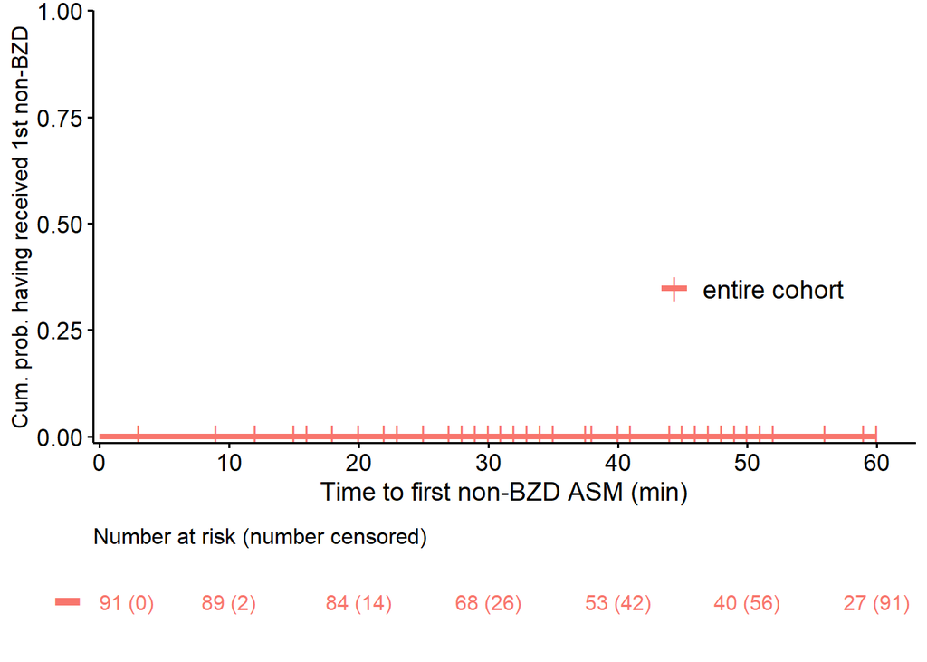

```r
# Non-BZD  ----------------

### Entire cohort

nonbzd <- survfit(Surv(pSERG$AEDtimeKM, pSERG$censtotal2) ~ 1)

nonbzdgeneral <- ggsurvplot(nonbzd, data = pSERG, fun = "event", censor = TRUE, censor.shape="|", censor.size=4.5,
     conf.int = FALSE, risk.table = "nrisk_cumcensor", tables.theme = theme_cleantable() , surv.median.line = "hv",  xlim = c(-0.5, 63), ylim = c(-0.015, 1), axes.offset=FALSE, break.y.by=0.25, break.x.by=10, tables.col="strata",   risk.table.pos="out", risk.table.fontsize=4, risk.table.y.text= F, legend = c(0.8, 0.4), legend.title="", font.x = c(14, "plain", "black"), font.y = c(12, "plain", "black"), font.tickslab=c(13, "plain", "black"), font.legend=c(14),  surv.plot.height = 0.78, risk.table.height=0.22, size=1.5,
               legend.labs=c("entire cohort"),
     xlab="Time to first non-BZD ASM (min)", ylab="Cum. prob. having received 1st non-BZD")
nonbzdgeneral$table <- nonbzdgeneral$table +
  theme(plot.title = element_text(size = 12, color = "black", face = "plain"))

nonbzdgeneral
```

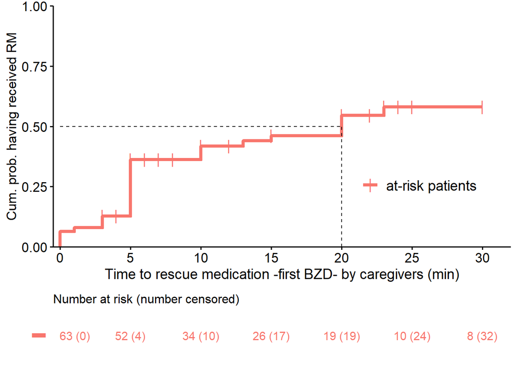

```r
# At-risk patients,  BZD -------------------

### All patients (at-risk patients)

Cent <- survfit(Surv(pSERG[which(pSERG$atrisk == 1), ]$BZDcaregiver, pSERG[which(pSERG$atrisk == 1), ]$censadmin2) ~ 1)

Centgeneral <- ggsurvplot(Cent, data = pSERG, fun = "event", censor = TRUE, censor.shape="|", censor.size=4.5,
     conf.int = FALSE, risk.table = "nrisk_cumcensor", tables.theme = theme_cleantable() , surv.median.line = "hv",  xlim = c(-0.5, 32), ylim = c(0, 1), axes.offset=FALSE, break.y.by=0.25, break.x.by=5, tables.col="strata",   risk.table.pos="out", risk.table.fontsize=4, risk.table.y.text= F, legend = c(0.8, 0.3), legend.title="", font.x = c(14, "plain", "black"), font.y = c(13, "plain", "black"), font.tickslab=c(13, "plain", "black"), font.legend=c(14),  surv.plot.height = 0.78, risk.table.height=0.22, size=1.5,
               legend.labs=c("at-risk patients"),
     xlab="Time to rescue medication -first BZD- by caregivers (min)", ylab="Cum. prob. having received RM")

Centgeneral$table <- Centgeneral$table +
  theme(plot.title = element_text(size = 12, color = "black", face = "plain"))

Centgeneral
```

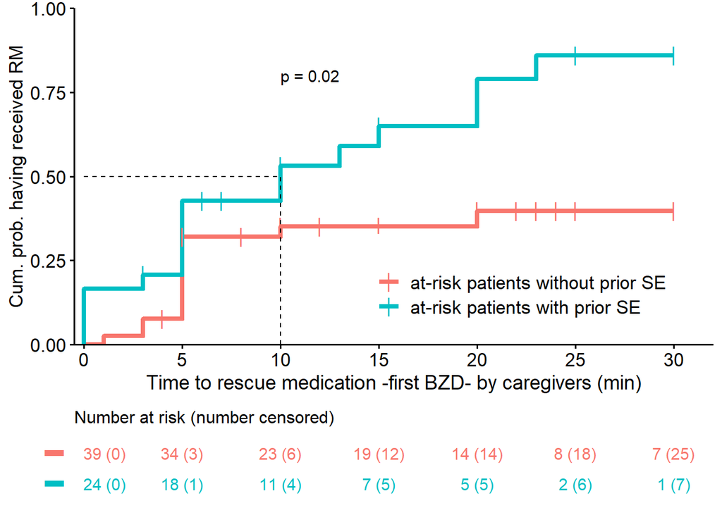

```r
### with SE or not (at-risk patients)

SEca <- survfit(Surv(pSERG[which(pSERG$atrisk == 1), ]$BZDcaregiver, pSERG[which(pSERG$atrisk == 1), ]$censadmin2) ~ pSERG[which(pSERG$atrisk == 1), ]$priorSE)

SEc <- ggsurvplot(SEca, data = pSERG, fun = "event", censor = TRUE, censor.shape="|", censor.size=4.5,
     conf.int = FALSE, pval=0.02, pval.coord=c(10, 0.8), pval.size=4, risk.table = "nrisk_cumcensor", tables.theme = theme_cleantable() , surv.median.line = "hv",  xlim = c(-0.5, 32), ylim = c(0, 1), axes.offset=FALSE, break.y.by=0.25, break.x.by=5, tables.col="strata",   risk.table.pos="out", risk.table.fontsize=4, risk.table.y.text= F, legend = c(0.7, 0.19), legend.title="", font.x = c(14, "plain", "black"), font.y = c(13, "plain", "black"), font.tickslab=c(13, "plain", "black"), font.legend=c(13),  surv.plot.height = 0.78, risk.table.height=0.22, size=1.5,
               legend.labs=c("at-risk patients without prior SE", "at-risk patients with prior SE"),
     xlab="Time to rescue medication -first BZD- by caregivers (min)", ylab="Cum. prob. having received RM")
SEc$table <- SEc$table +
  theme(plot.title = element_text(size = 12, color = "black", face = "plain"))

SEc
```

## Line chart with time intervals under caregiver and EMS care before the time to first BZD

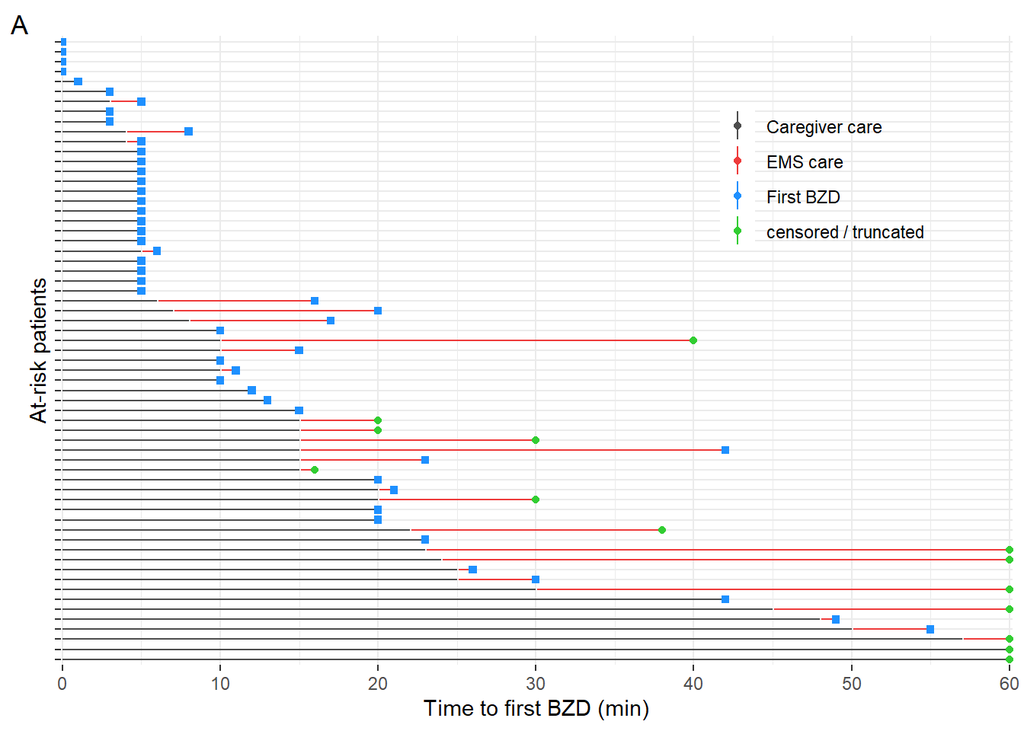

```r
# Prepare variables for the plot

 # 0 = seizure onset
 # 0-t1 = time within the care of caregiver, which ends when EMS arrival or when caregiver gives RM
 # t1-t2 = if not BZD administered, time within the care of EMS until first BZD administered or hospital arrival (or final figure, 60 minutes, censored/truncated line)
 # Square means first BZD, circle means censored patient (hospital arrival or > 60 minutes in total)


  # Create variable to define intervals
pSERG$caregiverforplot <- pSERG$EMSARRIVAL
pSERG$caregiverforplot <- ifelse(pSERG$EMSARRIVAL > 59, 60, pSERG$caregiverforplot)
pSERG$caregiverforplot <- ifelse(pSERG$BZDtimeKM < pSERG$EMSARRIVAL, pSERG$BZDtimeKM, pSERG$caregiverforplot)


   # Give a number to each patient and order based on first time interval for a more organized plot
pSERG$Patient <- 1:nrow(pSERG)
pSERG$Patiento <- factor(x = pSERG$Patient, levels = order(pSERG$caregiverforplot, decreasing = TRUE))

   # Convert to factor for the plot
pSERG$censtotal <- as.character(as.numeric(pSERG$censtotal))
pSERG$censtotal <- as.factor(as.character(pSERG$censtotal))



# LINE CHART with at-risk patient (A)

ggplot(pSERG[which(pSERG$atrisk == 1),], aes(x = Patiento)) +
    # Plot gray line representing time from 0 to t1
    geom_linerange(aes(ymin = 0, ymax = caregiverforplot, colour="gray30")) +
    # Plot red line representing time from t1 to t2
    geom_linerange(aes(ymin = caregiverforplot+ 0.1, ymax = BZDtimeKM, colour="brown2")) +
    # Plot points representing event or censoring
   geom_point(aes(y=BZDtimeKM, colour=factor(censtotal), shape=factor(censtotal))) +
    # Flip coordinates
    coord_flip() +
    # Customize image, colors, legend, labels, and axis
  scale_color_manual(name= "", values = c("limegreen", "dodgerblue1", "brown2","gray30"),   labels = c("censored / truncated", "First BZD", "EMS care", "Caregiver care"))+
    scale_shape_manual(values = c(19, 15)) +
    guides(shape=FALSE, color=guide_legend(reverse = TRUE)) +
      labs(y = "Time to first BZD (min)", x="At-risk patients", tag = "A") +
     theme_bw() + theme(panel.border = element_blank(), legend.position = c(0.8, 0.8),        legend.background= element_blank()) +
  scale_y_continuous(breaks=c(0, 10, 20, 30, 40, 50, 60), expand = c(0, 0.1)) +
    scale_x_discrete(labels=NULL)
```

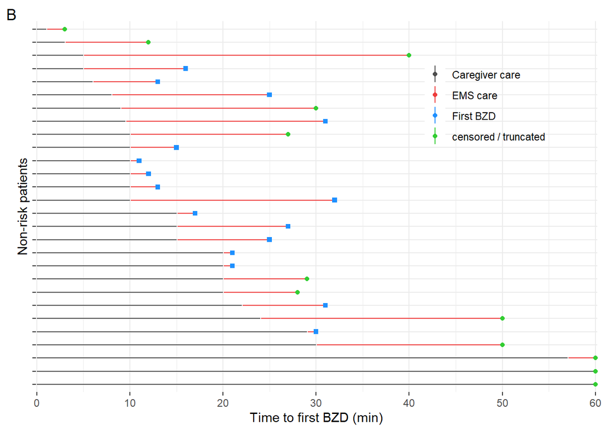

```r
# LINE CHART with patients without risk (B)

ggplot(pSERG[which(pSERG$atrisk == 0),], aes(x = Patiento)) +
    # Plot gray line representing time from 0 to t1
    geom_linerange(aes(ymin = 0, ymax = caregiverforplot, colour="gray30")) +
    # Plot red line representing time from t1 to t2
    geom_linerange(aes(ymin = caregiverforplot+ 0.1, ymax = BZDtimeKM, colour="brown2")) +
    # Plot points representing event or censoring
   geom_point(aes(y=BZDtimeKM, colour=factor(censtotal), shape=factor(censtotal))) +
    # Flip coordinates
    coord_flip() +
    # Customize image, colors, legend, labels, and axis
   scale_color_manual(name= "", values = c("limegreen", "dodgerblue1", "brown2","gray30"),    labels = c("censored / truncated", "First BZD", "EMS care", "Caregiver care"))+
      scale_shape_manual(values = c(19, 15)) +
    guides(shape=FALSE, color=guide_legend(reverse = TRUE)) +
      labs(y = "Time to first BZD (min)", x="Non-risk patients", tag = "B") +
     theme_bw() + theme(panel.border = element_blank(), legend.position = c(0.8, 0.8),        legend.background= element_blank()) +
   scale_y_continuous(breaks=c(0, 10, 20, 30, 40, 50, 60), expand = c(0, 0.1)) +
   scale_x_discrete(labels=NULL)
```

## To get demographic table of patients excluded to due to missing data on time intervals

Rename pSERG database and load the database again

```r
# Load pSERG database
pSERG <- read.csv("C:\\Users\\marta\\Documents\\PROJECTS\\EMS - PREHOSPITAL MANAGEMENT OF SE\\pserg_2020EMS.csv")
```

Clean the database. Keep only the population of interest and transform variables for analysis.

```r
# Keep only patients who have refractory status epilepticus
pSERG <- pSERG[which(pSERG$SE_GROUP == "refractory_case"), ]
dim(pSERG)
```

```
## [1]  502 1582
```

```r
# Keep only patients who have RSE initated outside the hospital
pSERG <- pSERG[which(pSERG$HOSPITALONSET == "no"), ]
dim(pSERG)
```

```
## [1]  340 1582
```

```r
# Time from SE onset to EMS arrival (EMSARRIVAL)
class(pSERG$EMSARRIVAL)
```

```
## [1] "factor"
```

```r
pSERG$EMSARRIVAL <- as.character(as.factor(pSERG$EMSARRIVAL))
pSERG$EMSARRIVAL <- as.numeric(as.character(pSERG$EMSARRIVAL))
# Time from SE onset to hospital arrival (HOSPITALARRIVAL)
class(pSERG$HOSPITALARRIVAL)
```

```
## [1] "factor"
```

```r
pSERG$HOSPITALARRIVAL <- as.character(as.factor(pSERG$HOSPITALARRIVAL))
pSERG$HOSPITALARRIVAL <- as.numeric(as.character(pSERG$HOSPITALARRIVAL))
# Time to first BZD (BZD.TIME0)
class(pSERG$BZDTIME.0)
```

```
## [1] "factor"
```

```r
pSERG$BZDTIME.0 <- as.character(as.factor(pSERG$BZDTIME.0))
pSERG$BZDTIME.0 <- as.numeric(as.character(pSERG$BZDTIME.0))
#Time to first AED (AED.TIME0)
class(pSERG$AEDTIME.0)
```

```
## [1] "factor"
```

```r
pSERG$AEDTIME.0 <- as.character(as.factor(pSERG$AEDTIME.0))
pSERG$AEDTIME.0 <- as.numeric(as.character(pSERG$AEDTIME.0))
# Time in the ambulance
pSERG$timeinambulance <- pSERG$HOSPITALARRIVAL - pSERG$EMSARRIVAL


# Transform date of status epilepticus onset into date format
pSERG$DATESEIZURE <- as.Date(pSERG$DATESEIZURE, format = "%m/%d/%Y")

# Order by patient and then by date of status epilepticus
pSERG <- pSERG[order(pSERG$PATIENT_LABEL, pSERG$DATESEIZURE), ]
```

Take only patients not included in the manuscript (exclude patients included already)

```r
dim(pSERG1)
```

```
## [1]   91 1583
```

```r
dim(pSERG)
```

```
## [1]  340 1583
```

```r
pSERGx <- anti_join(pSERG, pSERG1)
dim(pSERGx)
```

```
## [1]  249 1583
```

```r
pSERG <- pSERGx

# Transform date of status epilepticus onset into date format
pSERG$DATESEIZURE <- as.Date(pSERG$DATESEIZURE, format = "%m/%d/%Y")

# Order by patient and then by date of status epilepticus
pSERG <- pSERG[order(pSERG$PATIENT_LABEL, pSERG$DATESEIZURE), ]

# Delete duplicate episodes from the same patient
pSERG <- pSERG[!duplicated(pSERG$PATIENT_LABEL), ]
dim(pSERG)
```

```
## [1]  217 1583
```

```r
# New database with patients excluded and only one episode per patient
dim(pSERG)
```

```
## [1]  217 1583
```

## Demographic features of the excluded study population

```r
# Transform age into numeric
pSERG$G_T_STTS_PLPTCUS_EPISODE_YEARS <- as.numeric(as.character(pSERG$G_T_STTS_PLPTCUS_EPISODE_YEARS))
pSERG$G_T_STTS_PLPTCS_EPISODE_MONTHS <- as.numeric(as.character(pSERG$G_T_STTS_PLPTCS_EPISODE_MONTHS))
# Transform age into a single variable with age in years
pSERG$ageyears <- pSERG$G_T_STTS_PLPTCUS_EPISODE_YEARS + (pSERG$G_T_STTS_PLPTCS_EPISODE_MONTHS / 12)
# ------ Age
nobs(pSERG$ageyears)
```

```
## [1] 216
```

```r
summary(pSERG$ageyears)
```

```
##     Min.  1st Qu.   Median     Mean  3rd Qu.     Max.     NA's
##  0.08333  1.25000  3.66667  5.77799  9.43750 19.33333        1
```

```r
sd(pSERG$ageyears, na.rm = TRUE)
```

```
## [1] 5.330603
```

```r
pSERG$ageyearsx <- ifelse(pSERG$ageyears < 2, 1, 0)
table(pSERG$ageyearsx)
```

```
##
##   0   1
## 141  75
```

```r
class(pSERG$ageyearsx)
```

```
## [1] "numeric"
```

```r
# ---------- Sex
CrossTable(pSERG$SEX)
```

```
##
##
##    Cell Contents
## |-------------------------|
## |                       N |
## |         N / Table Total |
## |-------------------------|
##
##
## Total Observations in Table:  217
##
##
##           |    female |      male |
##           |-----------|-----------|
##           |        82 |       135 |
##           |     0.378 |     0.622 |
##           |-----------|-----------|
##
##
##
##
```

```r
pSERG$SEX <- ifelse((pSERG$SEX == "male"), 1, 0)
table(pSERG$SEX)
```

```
##
##   0   1
##  82 135
```

```r
class(pSERG$SEX)
```

```
## [1] "numeric"
```

```r
# ---------- Race
CrossTable(pSERG$RACE)
```

```
##
##
##    Cell Contents
## |-------------------------|
## |                       N |
## |         N / Table Total |
## |-------------------------|
##
##
## Total Observations in Table:  217
##
##
##                                     |       american_indian_alaska_native |                              arabic |                               asian |           black_or_african_american | native_hawaiian_or_pacific_islander |
##                                     |-------------------------------------|-------------------------------------|-------------------------------------|-------------------------------------|-------------------------------------|
##                                     |                                   1 |                                   4 |                                   7 |                                  39 |                                   1 |
##                                     |                               0.005 |                               0.018 |                               0.032 |                               0.180 |                               0.005 |
##                                     |-------------------------------------|-------------------------------------|-------------------------------------|-------------------------------------|-------------------------------------|
##
##
##                                     |                        not_reported |                             unknown |                               white |
##                                     |-------------------------------------|-------------------------------------|-------------------------------------|
##                                     |                                  11 |                                  11 |                                 143 |
##                                     |                               0.051 |                               0.051 |                               0.659 |
##                                     |-------------------------------------|-------------------------------------|-------------------------------------|
##
##
##
##
```

```r
# ---------- Ethnicity
CrossTable(pSERG$ETHNICITY)
```

```
##
##
##    Cell Contents
## |-------------------------|
## |                       N |
## |         N / Table Total |
## |-------------------------|
##
##
## Total Observations in Table:  217
##
##
##                        |     hispanic_or_latino | not_hispanic_or_latino |           not_reported |                unknown |
##                        |------------------------|------------------------|------------------------|------------------------|
##                        |                     43 |                    154 |                     10 |                     10 |
##                        |                  0.198 |                  0.710 |                  0.046 |                  0.046 |
##                        |------------------------|------------------------|------------------------|------------------------|
##
##
##
##
```

```r
# ---------- Etiology SE
table(pSERG$ETIOLOGY)
```

```
##
##               genetic  metabolic      other structural    unknown
##          5         53          5         31         50         73
```

```r
CrossTable(pSERG$ETIOLOGY)
```

```
##
##
##    Cell Contents
## |-------------------------|
## |                       N |
## |         N / Table Total |
## |-------------------------|
##
##
## Total Observations in Table:  217
##
##
##            |            |    genetic |  metabolic |      other | structural |
##            |------------|------------|------------|------------|------------|
##            |          5 |         53 |          5 |         31 |         50 |
##            |      0.023 |      0.244 |      0.023 |      0.143 |      0.230 |
##            |------------|------------|------------|------------|------------|
##
##
##            |    unknown |
##            |------------|
##            |         73 |
##            |      0.336 |
##            |------------|
##
##
##
##
```

```r
# ----------- Type of status epilepticus
CrossTable(pSERG$TYPESTATUS)
```

```
##
##
##    Cell Contents
## |-------------------------|
## |                       N |
## |         N / Table Total |
## |-------------------------|
##
##
## Total Observations in Table:  217
##
##
##              |   continuous | intermittent |
##              |--------------|--------------|
##              |           68 |          149 |
##              |        0.313 |        0.687 |
##              |--------------|--------------|
##
##
##
##
```

```r
pSERG$TYPESTATUS <- ifelse((pSERG$TYPESTATUS == "continuous"), 1, 0)
table(pSERG$TYPESTATUS)
```

```
##
##   0   1
## 149  68
```

```r
class(pSERG$TYPESTATUS)
```

```
## [1] "numeric"
```

```r
# Create variable history of developmental delay
pSERG$delay[grepl("delay", pSERG$PAST)] <- 1
pSERG$delay[!grepl("delay", pSERG$PAST)] <- 0
# ---------- History of developmental delay
CrossTable(pSERG$delay)
```

```
##
##
##    Cell Contents
## |-------------------------|
## |                       N |
## |         N / Table Total |
## |-------------------------|
##
##
## Total Observations in Table:  217
##
##
##           |         0 |         1 |
##           |-----------|-----------|
##           |       103 |       114 |
##           |     0.475 |     0.525 |
##           |-----------|-----------|
##
##
##
##
```

```r
class(pSERG$delay)
```

```
## [1] "numeric"
```

```r
# Create variable history of cerebral palsy
pSERG$palsy[grepl("palsy", pSERG$PAST)] <- 1
pSERG$palsy[!grepl("palsy", pSERG$PAST)] <- 0
# ---------- History of cerebral palsy
CrossTable(pSERG$palsy)
```

```
##
##
##    Cell Contents
## |-------------------------|
## |                       N |
## |         N / Table Total |
## |-------------------------|
##
##
## Total Observations in Table:  217
##
##
##           |         0 |         1 |
##           |-----------|-----------|
##           |       192 |        25 |
##           |     0.885 |     0.115 |
##           |-----------|-----------|
##
##
##
##
```

```r
# Create variable febrile
pSERG$febrile[grepl("febrile", pSERG$PAST)] <- 1
pSERG$febrile[!grepl("febrile", pSERG$PAST)] <- 0
# ---------- Febrile
CrossTable(pSERG$febrile)
```

```
##
##
##    Cell Contents
## |-------------------------|
## |                       N |
## |         N / Table Total |
## |-------------------------|
##
##
## Total Observations in Table:  217
##
##
##           |         0 |         1 |
##           |-----------|-----------|
##           |       198 |        19 |
##           |     0.912 |     0.088 |
##           |-----------|-----------|
##
##
##
##
```

```r
# Create variable history of epilepsy
pSERG$priorepilepsy[grepl("epi", pSERG$PAST)] <- 1
pSERG$priorepilepsy[!grepl("epi", pSERG$PAST)] <- 0
# ---------- History of prior epilepsy
CrossTable(pSERG$priorepilepsy)
```

```
##
##
##    Cell Contents
## |-------------------------|
## |                       N |
## |         N / Table Total |
## |-------------------------|
##
##
## Total Observations in Table:  217
##
##
##           |         0 |         1 |
##           |-----------|-----------|
##           |       107 |       110 |
##           |     0.493 |     0.507 |
##           |-----------|-----------|
##
##
##
##
```

```r
# Create variable history of status epilepticus
pSERG$priorSE[grepl("status", pSERG$PAST)] <- 1
pSERG$priorSE[!grepl("status", pSERG$PAST)] <- 0
# ---------- History of prior status epilepticus
CrossTable(pSERG$priorSE)
```

```
##
##
##    Cell Contents
## |-------------------------|
## |                       N |
## |         N / Table Total |
## |-------------------------|
##
##
## Total Observations in Table:  217
##
##
##           |         0 |         1 |
##           |-----------|-----------|
##           |       174 |        43 |
##           |     0.802 |     0.198 |
##           |-----------|-----------|
##
##
##
##
```

```r
class(pSERG$priorSE)
```

```
## [1] "numeric"
```

```r
# Create variable no prior neurological history
pSERG$none[grepl("none", pSERG$PAST)] <- 1
pSERG$none[!grepl("none", pSERG$PAST)] <- 0
# ---------- No prior neurological history
CrossTable(pSERG$none)
```

```
##
##
##    Cell Contents
## |-------------------------|
## |                       N |
## |         N / Table Total |
## |-------------------------|
##
##
## Total Observations in Table:  217
##
##
##           |         0 |         1 |
##           |-----------|-----------|
##           |       152 |        65 |
##           |     0.700 |     0.300 |
##           |-----------|-----------|
##
##
##
##
```

```r
# Transform convulsive duration into numeric
pSERG$CONVULSIVEDURATION <- as.numeric(as.character(pSERG$CONVULSIVEDURATION))
# Create convulsive duration in minutes
pSERG$convulsivemin <- pSERG$CONVULSIVEDURATION
pSERG$convulsivehr <- pSERG$CONVULSIVEDURATION * 60
pSERG$convulsivedurationmin <- ifelse(pSERG$CONVULSIVEDURATIONUNITS == "min", pSERG$convulsivemin, pSERG$convulsivehr)
# ----------- Duration of convulsive status epilepticus
nobs(pSERG$convulsivedurationmin)
```

```
## [1] 202
```

```r
summary(pSERG$convulsivedurationmin)
```

```
##      Min.   1st Qu.    Median      Mean   3rd Qu.      Max.      NA's
##      0.00     60.75    178.00   2472.45    517.50 172800.00        15
```

```r
sd(pSERG$convulsivedurationmin, na.rm = TRUE)
```

```
## [1] 14102.59
```

```r
# Create variables for history of febrile sz as current risk factor (excludes patients currently diagnosed of epilepsy and patients older than 5 years)
table(pSERG$febrile)
```

```
##
##   0   1
## 198  19
```

```r
pSERG$febrilesz <- ifelse(pSERG$febrile == 1 & pSERG$priorepilepsy == 0 & pSERG$ageyears < 6, 1, 0)
CrossTable(pSERG$febrilesz)
```

```
##
##
##    Cell Contents
## |-------------------------|
## |                       N |
## |         N / Table Total |
## |-------------------------|
##
##
## Total Observations in Table:  217
##
##
##           |         0 |         1 |
##           |-----------|-----------|
##           |       209 |         8 |
##           |     0.963 |     0.037 |
##           |-----------|-----------|
##
##
##
##
```

```r
# Check how many patients with prior history of SE are epilepsy patients, patients with febrile sz or none of them.
CrossTable(pSERG$priorSE)
```

```
##
##
##    Cell Contents
## |-------------------------|
## |                       N |
## |         N / Table Total |
## |-------------------------|
##
##
## Total Observations in Table:  217
##
##
##           |         0 |         1 |
##           |-----------|-----------|
##           |       174 |        43 |
##           |     0.802 |     0.198 |
##           |-----------|-----------|
##
##
##
##
```

```r
CrossTable(pSERG[which(pSERG$priorSE == 1), ]$priorepilepsy )
```

```
##
##
##    Cell Contents
## |-------------------------|
## |                       N |
## |         N / Table Total |
## |-------------------------|
##
##
## Total Observations in Table:  43
##
##
##           |         0 |         1 |
##           |-----------|-----------|
##           |        10 |        33 |
##           |     0.233 |     0.767 |
##           |-----------|-----------|
##
##
##
##
```

```r
CrossTable(pSERG[which(pSERG$priorSE == 1), ]$febrilesz )
```

```
##
##
##    Cell Contents
## |-------------------------|
## |                       N |
## |         N / Table Total |
## |-------------------------|
##
##
## Total Observations in Table:  43
##
##
##           |         0 |         1 |
##           |-----------|-----------|
##           |        41 |         2 |
##           |     0.953 |     0.047 |
##           |-----------|-----------|
##
##
##
##
```

```r
CrossTable(pSERG[which(!pSERG$febrilesz == 1 & !pSERG$priorepilepsy == 1), ]$priorSE )
```

```
##
##
##    Cell Contents
## |-------------------------|
## |                       N |
## |         N / Table Total |
## |-------------------------|
##
##
## Total Observations in Table:  99
##
##
##           |         0 |         1 |
##           |-----------|-----------|
##           |        91 |         8 |
##           |     0.919 |     0.081 |
##           |-----------|-----------|
##
##
##
##
```

```r
# Check how many patients with prior history of epilepsy had a prior SE
CrossTable(pSERG[which(pSERG$priorepilepsy == 1), ]$priorSE )
```

```
##
##
##    Cell Contents
## |-------------------------|
## |                       N |
## |         N / Table Total |
## |-------------------------|
##
##
## Total Observations in Table:  110
##
##
##           |         0 |         1 |
##           |-----------|-----------|
##           |        77 |        33 |
##           |     0.700 |     0.300 |
##           |-----------|-----------|
##
##
##
##
```

```r
# Check how many patients with prior history of febrilesz had a prior SE
CrossTable(pSERG[which(pSERG$febrilesz == 1), ]$priorSE )
```

```
##
##
##    Cell Contents
## |-------------------------|
## |                       N |
## |         N / Table Total |
## |-------------------------|
##
##
## Total Observations in Table:  8
##
##
##           |         0 |         1 |
##           |-----------|-----------|
##           |         6 |         2 |
##           |     0.750 |     0.250 |
##           |-----------|-----------|
##
##
##
##
```

```r
# Define at-risk patient for sz (prior epilepsy, prior febrile sz in young patient, prior SE)
pSERG$atrisk <- ifelse(pSERG$priorepilepsy ==1 | pSERG$priorSE == 1 | pSERG$febrilesz == 1, 1, 0)
CrossTable(pSERG$atrisk)
```

```
##
##
##    Cell Contents
## |-------------------------|
## |                       N |
## |         N / Table Total |
## |-------------------------|
##
##
## Total Observations in Table:  217
##
##
##           |         0 |         1 |
##           |-----------|-----------|
##           |        91 |       126 |
##           |     0.419 |     0.581 |
##           |-----------|-----------|
##
##
##
##
```

```r
# Intubation needed
CrossTable(pSERG$INTUBATION)
```

```
##
##
##    Cell Contents
## |-------------------------|
## |                       N |
## |         N / Table Total |
## |-------------------------|
##
##
## Total Observations in Table:  217
##
##
##           |           |        no |       yes |
##           |-----------|-----------|-----------|
##           |         6 |        73 |       138 |
##           |     0.028 |     0.336 |     0.636 |
##           |-----------|-----------|-----------|
##
##
##
##
```